# Project: Identify Customer Segments

In this project, you will apply unsupervised learning techniques to identify segments of the population that form the core customer base for a mail-order sales company in Germany. These segments can then be used to direct marketing campaigns towards audiences that will have the highest expected rate of returns. The data that you will use has been provided by our partners at Bertelsmann Arvato Analytics, and represents a real-life data science task.

This notebook will help you complete this task by providing a framework within which you will perform your analysis steps. In each step of the project, you will see some text describing the subtask that you will perform, followed by one or more code cells for you to complete your work. **Feel free to add additional code and markdown cells as you go along so that you can explore everything in precise chunks.** The code cells provided in the base template will outline only the major tasks, and will usually not be enough to cover all of the minor tasks that comprise it.

It should be noted that while there will be precise guidelines on how you should handle certain tasks in the project, there will also be places where an exact specification is not provided. **There will be times in the project where you will need to make and justify your own decisions on how to treat the data.** These are places where there may not be only one way to handle the data. In real-life tasks, there may be many valid ways to approach an analysis task. One of the most important things you can do is clearly document your approach so that other scientists can understand the decisions you've made.

At the end of most sections, there will be a Markdown cell labeled **Discussion**. In these cells, you will report your findings for the completed section, as well as document the decisions that you made in your approach to each subtask. **Your project will be evaluated not just on the code used to complete the tasks outlined, but also your communication about your observations and conclusions at each stage.**

```python
# import libraries here; add more as necessary
import numpy as np
import pandas as pd
import matplotlib.pyplot as plt
import seaborn as sns

import sklearn
from sklearn.preprocessing import OneHotEncoder
from sklearn.impute import SimpleImputer

# magic word for producing visualizations in notebook
%matplotlib inline

pd.options.display.max_rows = None
pd.options.display.max_columns = None
```

### Step 0: Load the Data

Each row of the demographics files represents a single person, but also includes information outside of individuals, including information about their household, building, and neighborhood. You will use this information to cluster the general population into groups with similar demographic properties. Then, you will see how the people in the customers dataset fit into those created clusters. The hope here is that certain clusters are over-represented in the customers data, as compared to the general population; those over-represented clusters will be assumed to be part of the core userbase. This information can then be used for further applications, such as targeting for a marketing campaign.

To start off with, load in the demographics data for the general population into a pandas DataFrame, and do the same for the feature attributes summary. Note for all of the `.csv` data files in this project: they're semicolon (`;`) delimited, so you'll need an additional argument in your [`read_csv()`](https://pandas.pydata.org/pandas-docs/stable/generated/pandas.read_csv.html) call to read in the data properly. Also, considering the size of the main dataset, it may take some time for it to load completely.

Once the dataset is loaded, it's recommended that you take a little bit of time just browsing the general structure of the dataset and feature summary file. You'll be getting deep into the innards of the cleaning in the first major step of the project, so gaining some general familiarity can help you get your bearings.

```python
# Load in the general demographics data.
df_demograph= pd.read_csv('Udacity_AZDIAS_Subset.csv', sep=';')
```

```python
# Load in the feature summary file.
df_feature_summary= pd.read_csv('AZDIAS_Feature_Summary.csv',delimiter=';')
```

```python
# Check the structure of the data after it's loaded (e.g. print the number of
# rows and columns, print the first few rows).
df_demograph.head()
```

|  | AGER_TYP | ALTERSKATEGORIE_GROB | ANREDE_KZ | CJT_GESAMTTYP | FINANZ_MINIMALIST | FINANZ_SPARER | FINANZ_VORSORGER | FINANZ_ANLEGER | FINANZ_UNAUFFAELLIGER | FINANZ_HAUSBAUER | FINANZTYP | GEBURTSJAHR | GFK_URLAUBERTYP | GREEN_AVANTGARDE | HEALTH_TYP | LP_LEBENSPHASE_FEIN | LP_LEBENSPHASE_GROB | LP_FAMILIE_FEIN | LP_FAMILIE_GROB | LP_STATUS_FEIN | LP_STATUS_GROB | NATIONALITAET_KZ | PRAEGENDE_JUGENDJAHRE | RETOURTYP_BK_S | SEMIO_SOZ | SEMIO_FAM | SEMIO_REL | SEMIO_MAT | SEMIO_VERT | … |
| --- | --- | --- | --- | --- | --- | --- | --- | --- | --- | --- | --- | --- | --- | --- | --- | --- | --- | --- | --- | --- | --- | --- | --- | --- | --- | --- | --- | --- | --- | --- |
| 0 | -1 | 2 | 1 | 2.0 | 3 | 4 | 3 | 5 | 5 | 3 | 4 | 0 | 10.0 | 0 | -1 | 15.0 | 4.0 | 2.0 | 2.0 | 1.0 | 1.0 | 0 | 0 | 5.0 | 2 | 6 | 7 | 5 | 1 | … |
| 1 | -1 | 1 | 2 | 5.0 | 1 | 5 | 2 | 5 | 4 | 5 | 1 | 1996 | 10.0 | 0 | 3 | 21.0 | 6.0 | 5.0 | 3.0 | 2.0 | 1.0 | 1 | 14 | 1.0 | 5 | 4 | 4 | 3 | 1 | … |
| 2 | -1 | 3 | 2 | 3.0 | 1 | 4 | 1 | 2 | 3 | 5 | 1 | 1979 | 10.0 | 1 | 3 | 3.0 | 1.0 | 1.0 | 1.0 | 3.0 | 2.0 | 1 | 15 | 3.0 | 4 | 1 | 3 | 3 | 4 | … |
| 3 | 2 | 4 | 2 | 2.0 | 4 | 2 | 5 | 2 | 1 | 2 | 6 | 1957 | 1.0 | 0 | 2 | 0.0 | 0.0 | 0.0 | 0.0 | 9.0 | 4.0 | 1 | 8 | 2.0 | 5 | 1 | 2 | 1 | 4 | … |
| 4 | -1 | 3 | 1 | 5.0 | 4 | 3 | 4 | 1 | 3 | 2 | 5 | 1963 | 5.0 | 0 | 3 | 32.0 | 10.0 | 10.0 | 5.0 | 3.0 | 2.0 | 1 | 8 | 5.0 | 6 | 4 | 4 | 2 | 7 | … |

```python
df_demograph.shape
```

```
(891221, 85)
```

```python
df_demograph.info()
```

```
<class 'pandas.core.frame.DataFrame'>
RangeIndex: 891221 entries, 0 to 891220
Data columns (total 85 columns):
 #   Column                 Non-Null Count   Dtype
---  ------                 --------------   -----
 0   AGER_TYP               891221 non-null  int64
 1   ALTERSKATEGORIE_GROB   891221 non-null  int64
 2   ANREDE_KZ              891221 non-null  int64
 3   CJT_GESAMTTYP          886367 non-null  float64
 4   FINANZ_MINIMALIST      891221 non-null  int64
 5   FINANZ_SPARER          891221 non-null  int64
 6   FINANZ_VORSORGER       891221 non-null  int64
 7   FINANZ_ANLEGER         891221 non-null  int64
 8   FINANZ_UNAUFFAELLIGER  891221 non-null  int64
 9   FINANZ_HAUSBAUER       891221 non-null  int64
```

[output cut: 77 more lines]

```python
df_demograph.describe()
```

|  | AGER_TYP | ALTERSKATEGORIE_GROB | ANREDE_KZ | CJT_GESAMTTYP | FINANZ_MINIMALIST | FINANZ_SPARER | FINANZ_VORSORGER | FINANZ_ANLEGER | FINANZ_UNAUFFAELLIGER | FINANZ_HAUSBAUER | FINANZTYP | GEBURTSJAHR | GFK_URLAUBERTYP | GREEN_AVANTGARDE | HEALTH_TYP | LP_LEBENSPHASE_FEIN | LP_LEBENSPHASE_GROB | LP_FAMILIE_FEIN | LP_FAMILIE_GROB | LP_STATUS_FEIN | LP_STATUS_GROB | NATIONALITAET_KZ | PRAEGENDE_JUGENDJAHRE | RETOURTYP_BK_S | SEMIO_SOZ | SEMIO_FAM | SEMIO_REL | SEMIO_MAT | SEMIO_VERT | … |
| --- | --- | --- | --- | --- | --- | --- | --- | --- | --- | --- | --- | --- | --- | --- | --- | --- | --- | --- | --- | --- | --- | --- | --- | --- | --- | --- | --- | --- | --- | --- |
| count | 891221.000000 | 891221.000000 | 891221.000000 | 886367.000000 | 891221.000000 | 891221.000000 | 891221.000000 | 891221.000000 | 891221.000000 | 891221.000000 | 891221.000000 | 891221.000000 | 886367.000000 | 891221.000000 | 891221.000000 | 886367.000000 | 886367.000000 | 886367.000000 | 886367.000000 | 886367.000000 | 886367.000000 | 891221.000000 | 891221.000000 | 886367.000000 | 891221.000000 | 891221.000000 | 891221.000000 | 891221.000000 | 891221.000000 | … |
| mean | -0.358435 | 2.777398 | 1.522098 | 3.632838 | 3.074528 | 2.821039 | 3.401106 | 3.033328 | 2.874167 | 3.075121 | 3.790586 | 1101.178533 | 7.350304 | 0.196612 | 1.792102 | 14.622637 | 4.453621 | 3.599574 | 2.185966 | 4.791151 | 2.432575 | 1.026827 | 8.154346 | 3.419630 | 3.945860 | 4.272729 | 4.240609 | 4.001597 | 4.023709 | … |
| std | 1.198724 | 1.068775 | 0.499512 | 1.595021 | 1.321055 | 1.464749 | 1.322134 | 1.529603 | 1.486731 | 1.353248 | 1.987876 | 976.583551 | 3.525723 | 0.397437 | 1.269062 | 12.616883 | 3.855639 | 3.926486 | 1.756537 | 3.425305 | 1.474315 | 0.586634 | 4.844532 | 1.417741 | 1.946564 | 1.915885 | 2.007373 | 1.857540 | 2.077746 | … |
| min | -1.000000 | 1.000000 | 1.000000 | 1.000000 | 1.000000 | 1.000000 | 1.000000 | 1.000000 | 1.000000 | 1.000000 | 1.000000 | 0.000000 | 1.000000 | 0.000000 | -1.000000 | 0.000000 | 0.000000 | 0.000000 | 0.000000 | 1.000000 | 1.000000 | 0.000000 | 0.000000 | 1.000000 | 1.000000 | 1.000000 | 1.000000 | 1.000000 | 1.000000 | … |
| 25% | -1.000000 | 2.000000 | 1.000000 | 2.000000 | 2.000000 | 1.000000 | 3.000000 | 2.000000 | 2.000000 | 2.000000 | 2.000000 | 0.000000 | 5.000000 | 0.000000 | 1.000000 | 4.000000 | 1.000000 | 1.000000 | 1.000000 | 2.000000 | 1.000000 | 1.000000 | 5.000000 | 2.000000 | 2.000000 | 3.000000 | 3.000000 | 2.000000 | 2.000000 | … |
| 50% | -1.000000 | 3.000000 | 2.000000 | 4.000000 | 3.000000 | 3.000000 | 3.000000 | 3.000000 | 3.000000 | 3.000000 | 4.000000 | 1943.000000 | 8.000000 | 0.000000 | 2.000000 | 11.000000 | 3.000000 | 1.000000 | 1.000000 | 4.000000 | 2.000000 | 1.000000 | 8.000000 | 3.000000 | 4.000000 | 4.000000 | 4.000000 | 4.000000 | 4.000000 | … |
| 75% | -1.000000 | 4.000000 | 2.000000 | 5.000000 | 4.000000 | 4.000000 | 5.000000 | 5.000000 | 4.000000 | 4.000000 | 6.000000 | 1970.000000 | 10.000000 | 0.000000 | 3.000000 | 27.000000 | 8.000000 | 8.000000 | 4.000000 | 9.000000 | 4.000000 | 1.000000 | 14.000000 | 5.000000 | 6.000000 | 6.000000 | 6.000000 | 5.000000 | 6.000000 | … |
| max | 3.000000 | 9.000000 | 2.000000 | 6.000000 | 5.000000 | 5.000000 | 5.000000 | 5.000000 | 5.000000 | 5.000000 | 6.000000 | 2017.000000 | 12.000000 | 1.000000 | 3.000000 | 40.000000 | 12.000000 | 11.000000 | 5.000000 | 10.000000 | 5.000000 | 3.000000 | 15.000000 | 5.000000 | 7.000000 | 7.000000 | 7.000000 | 7.000000 | 7.000000 | … |

```python
df_feature_summary.head()
```

|  | attribute | information_level | type | missing_or_unknown |
| --- | --- | --- | --- | --- |
| 0 | AGER_TYP | person | categorical | [-1,0] |
| 1 | ALTERSKATEGORIE_GROB | person | ordinal | [-1,0,9] |
| 2 | ANREDE_KZ | person | categorical | [-1,0] |
| 3 | CJT_GESAMTTYP | person | categorical | [0] |
| 4 | FINANZ_MINIMALIST | person | ordinal | [-1] |

```python
df_feature_summary.shape
```

```
(85, 4)
```

```python
df_feature_summary.info()
```

```
<class 'pandas.core.frame.DataFrame'>
RangeIndex: 85 entries, 0 to 84
Data columns (total 4 columns):
 #   Column              Non-Null Count  Dtype
---  ------              --------------  -----
 0   attribute           85 non-null     object
 1   information_level   85 non-null     object
 2   type                85 non-null     object
 3   missing_or_unknown  85 non-null     object
dtypes: object(4)
memory usage: 2.8+ KB
```

```python
df_feature_summary.describe()
```

|  | attribute | information_level | type | missing_or_unknown |
| --- | --- | --- | --- | --- |
| count | 85 | 85 | 85 | 85 |
| unique | 85 | 9 | 5 | 9 |
| top | AGER_TYP | person | ordinal | [-1] |
| freq | 1 | 43 | 49 | 26 |

```python
# Set column names based on provided structure
attribute_col = 'attribute'
missing_col = 'missing_or_unknown'

# Extract relevant columns
missing_info = df_feature_summary[[attribute_col, missing_col]].copy()

# Function to parse the 'missing_or_unknown' column
def parse_missing_codes(code_str):
    code_str = code_str.strip('[]').strip()
    if code_str == '':
        return []
    codes = []
    for val in code_str.split(','):
        val = val.strip()
        # Check if val is an integer (including negative signs)
        if val.lstrip('-').isdigit():
            codes.append(int(val))
        # Otherwise, skip the value
    return codes

# Parse missing codes into a new column
missing_info['Missing Codes'] = missing_info[missing_col].apply(parse_missing_codes)

# Replace missing/unknown codes in df_demograph with NaN
for idx, row in missing_info.iterrows():
    feature = row[attribute_col]
    missing_codes = row['Missing Codes']
    if feature in df_demograph.columns and missing_codes:
        df_demograph[feature] = df_demograph[feature].replace(missing_codes, np.nan)

# Check how many missing values now exist after the replacement
missing_counts = df_demograph.isnull().sum()
print("\nMissing Values After Replacement:")
print(missing_counts[missing_counts > 0])
```

```
Missing Values After Replacement:
AGER_TYP                 685843
ALTERSKATEGORIE_GROB       2881
CJT_GESAMTTYP              4854
GEBURTSJAHR              392318
GFK_URLAUBERTYP            4854
HEALTH_TYP               111196
LP_LEBENSPHASE_FEIN       97632
LP_LEBENSPHASE_GROB       94572
LP_FAMILIE_FEIN           77792
LP_FAMILIE_GROB           77792
LP_STATUS_FEIN             4854
LP_STATUS_GROB             4854
NATIONALITAET_KZ         108315
PRAEGENDE_JUGENDJAHRE    108164
RETOURTYP_BK_S             4854
SHOPPER_TYP              111196
SOHO_KZ                   73499
TITEL_KZ                 889061
VERS_TYP                 111196
ALTER_HH                 310267
ANZ_PERSONEN              73499
ANZ_TITEL                 73499
HH_EINKOMMEN_SCORE        18348
KK_KUNDENTYP             584612
W_KEIT_KIND_HH           147988
WOHNDAUER_2008            73499
ANZ_HAUSHALTE_AKTIV       99611
ANZ_HH_TITEL              97008
GEBAEUDETYP               93148
KONSUMNAEHE               73969
MIN_GEBAEUDEJAHR          93148
OST_WEST_KZ               93148
WOHNLAGE                  93148
CAMEO_DEUG_2015           98979
CAMEO_DEU_2015            98979
CAMEO_INTL_2015           98979
KBA05_ANTG1              133324
KBA05_ANTG2              133324
KBA05_ANTG3              133324
```

[output cut: 8 more lines]

```
MOBI_REGIO               133324
ONLINE_AFFINITAET          4854
REGIOTYP                 158064
KBA13_ANZAHL_PKW         105800
PLZ8_ANTG1               116515
PLZ8_ANTG2               116515
PLZ8_ANTG3               116515
PLZ8_ANTG4               116515
PLZ8_BAUMAX              116515
PLZ8_HHZ                 116515
PLZ8_GBZ                 116515
ARBEIT                    97375
ORTSGR_KLS9               97274
RELAT_AB                  97375
dtype: int64
```

```python
df_demograph.isna().sum()[df_demograph.isna().sum()>0].count()
```

```
61
```

#### Step 1.1.2: Assess Missing Data in Each Column

How much missing data is present in each column? There are a few columns that are outliers in terms of the proportion of values that are missing. You will want to use matplotlib's [`hist()`](https://matplotlib.org/api/_as_gen/matplotlib.pyplot.hist.html) function to visualize the distribution of missing value counts to find these columns. Identify and document these columns. While some of these columns might have justifications for keeping or re-encoding the data, for this project you should just remove them from the dataframe. (Feel free to make remarks about these outlier columns in the discussion, however!)

For the remaining features, are there any patterns in which columns have, or share, missing data?

```python
# Perform an assessment of how much missing data there is in each column of the
# dataset.
# Calculate the count of missing values in each column
missing_counts = df_demograph.isnull().sum()

# Calculate the percentage of missing values in each column
missing_percent = (missing_counts / len(df_demograph)) * 100

# Combine into a single DataFrame for easier inspection
missing_data = pd.DataFrame({'Missing Count': missing_counts, 'Missing Percent': missing_percent})

# Sort by the column with the most missing data
missing_data = missing_data.sort_values(by='Missing Percent', ascending=False)

# Display the missing data summary
display(missing_data)
```

|  | Missing Count | Missing Percent |
| --- | --- | --- |
| TITEL_KZ | 889061 | 99.757636 |
| AGER_TYP | 685843 | 76.955435 |
| KK_KUNDENTYP | 584612 | 65.596749 |
| KBA05_BAUMAX | 476524 | 53.468668 |
| GEBURTSJAHR | 392318 | 44.020282 |
| ALTER_HH | 310267 | 34.813699 |
| KKK | 158064 | 17.735668 |
| REGIOTYP | 158064 | 17.735668 |
| W_KEIT_KIND_HH | 147988 | 16.605084 |
| KBA05_ANTG1 | 133324 | 14.959701 |
| KBA05_ANTG2 | 133324 | 14.959701 |
| KBA05_ANTG3 | 133324 | 14.959701 |
| KBA05_ANTG4 | 133324 | 14.959701 |
| KBA05_GBZ | 133324 | 14.959701 |
| MOBI_REGIO | 133324 | 14.959701 |
| PLZ8_ANTG3 | 116515 | 13.073637 |
| PLZ8_ANTG2 | 116515 | 13.073637 |
| PLZ8_GBZ | 116515 | 13.073637 |
| PLZ8_HHZ | 116515 | 13.073637 |
| PLZ8_ANTG1 | 116515 | 13.073637 |
| PLZ8_BAUMAX | 116515 | 13.073637 |
| PLZ8_ANTG4 | 116515 | 13.073637 |
| VERS_TYP | 111196 | 12.476816 |
| HEALTH_TYP | 111196 | 12.476816 |
| SHOPPER_TYP | 111196 | 12.476816 |
| NATIONALITAET_KZ | 108315 | 12.153551 |
| PRAEGENDE_JUGENDJAHRE | 108164 | 12.136608 |
| KBA13_ANZAHL_PKW | 105800 | 11.871354 |
| ANZ_HAUSHALTE_AKTIV | 99611 | 11.176913 |
| CAMEO_INTL_2015 | 98979 | 11.106000 |

[output cut: 55 more lines]

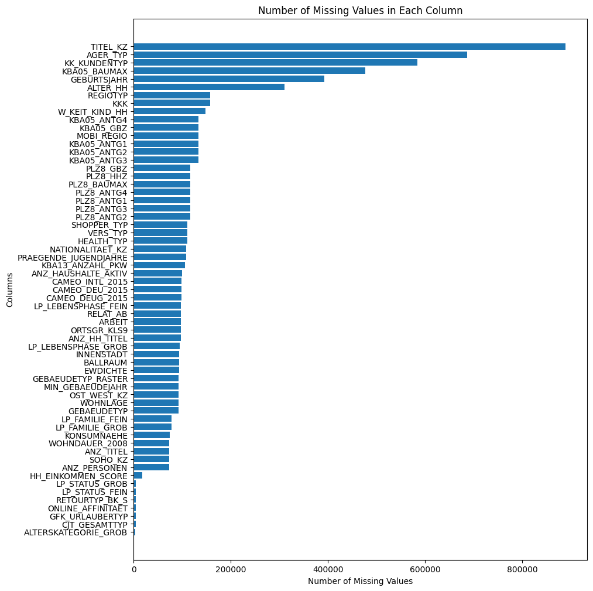

```python
missing_data = df_demograph.isna().sum()
missing_data = missing_data[missing_data > 0]
missing_data = missing_data.sort_values() #ascending=True

plt.figure(figsize=(10,12))

plt.barh(missing_data.index, missing_data.values)
plt.title('Number of Missing Values in Each Column')
plt.ylabel('Columns')
plt.xlabel('Number of Missing Values')
plt.show()
```

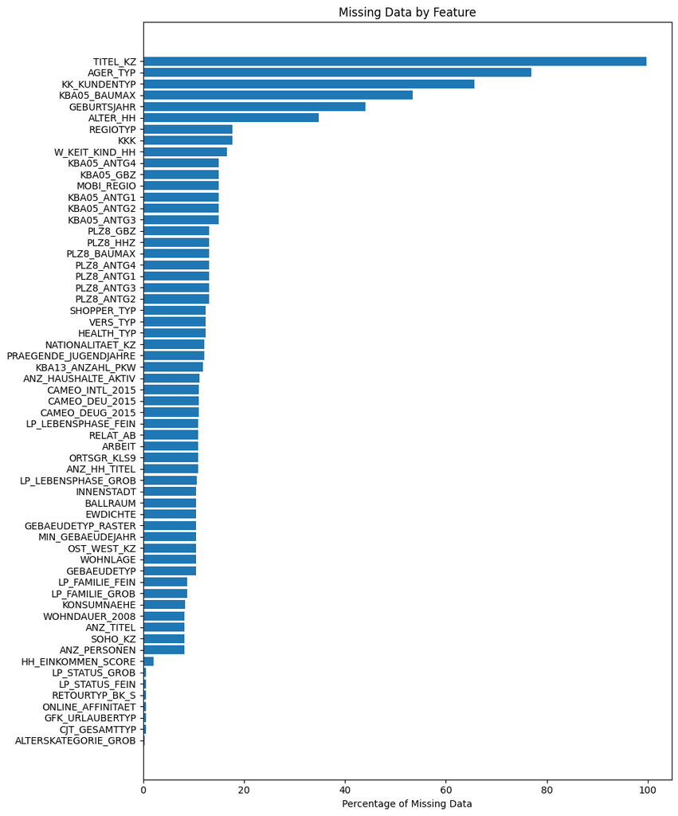

```python
# Investigate patterns in the amount of missing data in each column.
missing_percent = (df_demograph.isnull().sum() / len(df_demograph)) * 100
missing_percent = missing_percent[missing_percent > 0].sort_values()

plt.figure(figsize=(10, 12))
plt.barh(missing_percent.index, missing_percent.values)
plt.xlabel('Percentage of Missing Data')
plt.title('Missing Data by Feature')
plt.tight_layout()
plt.show()
```

#### Discussion 1.1.2: Assess Missing Data in Each Column

> 1. Demographic & Geographic Features:
> - Features like `ALTER_HH`, `GEBURTSJAHR`, and `AGER_TYP` had significant missingness. These are person-specific demographics, which might be missing due to privacy or non-response.
> - Several PLZ (postal code) related variables had ~13% missing values, indicating geographical data may not be uniformly available.
> 2. Marketing/Customer Segmentation Codes:
> - `TITEL_KZ`, `KK_KUNDENTYP`, `CAMEO_*`, etc., are highly engineered or commercial segmentation variables and were often missing, likely because not all individuals are categorized.
> 3. Low-Missing Variables:
> - Many `SEMIO_*` and `FINANZ_*` variables had 0% missingness, making them strong candidates for modeling.
> - Variables like `HH_EINKOMMEN_SCORE` had <3% missing data, which is manageable with imputation.

#### Step 1.1.3: Assess Missing Data in Each Row

Now, you'll perform a similar assessment for the rows of the dataset. How much data is missing in each row? As with the columns, you should see some groups of points that have a very different numbers of missing values. Divide the data into two subsets: one for data points that are above some threshold for missing values, and a second subset for points below that threshold.

In order to know what to do with the outlier rows, we should see if the distribution of data values on columns that are not missing data (or are missing very little data) are similar or different between the two groups. Select at least five of these columns and compare the distribution of values.

- You can use seaborn's [`countplot()`](https://seaborn.pydata.org/generated/seaborn.countplot.html) function to create a bar chart of code frequencies and matplotlib's [`subplot()`](https://matplotlib.org/api/_as_gen/matplotlib.pyplot.subplot.html) function to put bar charts for the two subplots side by side.
- To reduce repeated code, you might want to write a function that can perform this comparison, taking as one of its arguments a column to be compared.

Depending on what you observe in your comparison, this will have implications on how you approach your conclusions later in the analysis. If the distributions of non-missing features look similar between the data with many missing values and the data with few or no missing values, then we could argue that simply dropping those points from the analysis won't present a major issue. On the other hand, if the data with many missing values looks very different from the data with few or no missing values, then we should make a note on those data as special. We'll revisit these data later on. **Either way, you should continue your analysis for now using just the subset of the data with few or no missing values.**

```python
# How much data is missing in each row of the dataset?
# Count the number of missing values per row
row_missing_counts = df_demograph.isnull().sum(axis=1)

# Calculate the percentage of missing values per row
row_missing_percent = (row_missing_counts / df_demograph.shape[1]) * 100

# Combine into a single DataFrame for inspection
missing_by_row = pd.DataFrame({
    'Missing Count': row_missing_counts,
    'Missing Percent': row_missing_percent
})

print(missing_by_row.head())  # Check the first few rows
print("\nSummary statistics for missing data per row:")
print(missing_by_row['Missing Percent'].describe())
```

```
   Missing Count  Missing Percent
0             43        54.430380
1              0         0.000000
2              0         0.000000
3              7         8.860759
4              0         0.000000

Summary statistics for missing data per row:
count    891221.000000
mean          7.150175
std          16.752818
min           0.000000
25%           0.000000
50%           0.000000
75%           3.797468
max          62.025316
Name: Missing Percent, dtype: float64
```

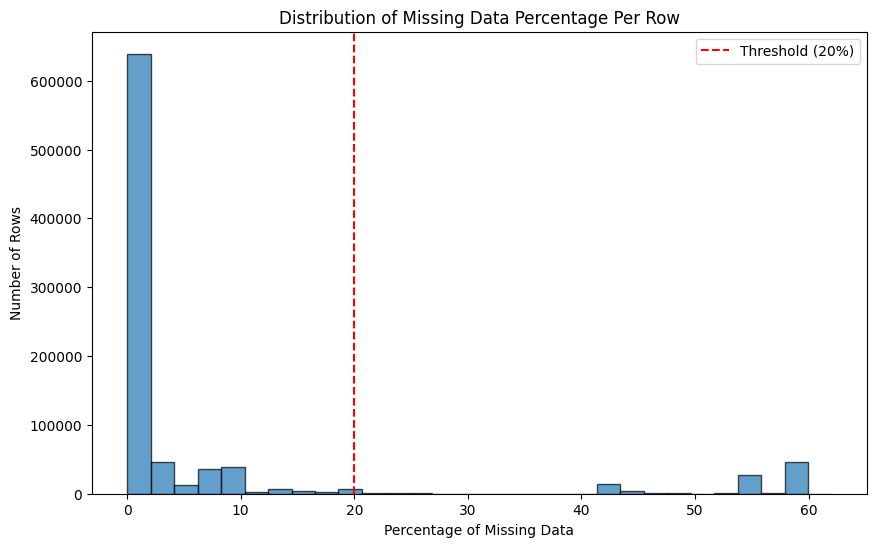

```python
plt.figure(figsize=(10, 6))
plt.hist(row_missing_percent, bins=30, edgecolor="k", alpha=0.7)
plt.axvline(20, color='red', linestyle='--', label='Threshold (20%)')
plt.title("Distribution of Missing Data Percentage Per Row")
plt.xlabel("Percentage of Missing Data")
plt.ylabel("Number of Rows")
plt.legend()
plt.show()
```

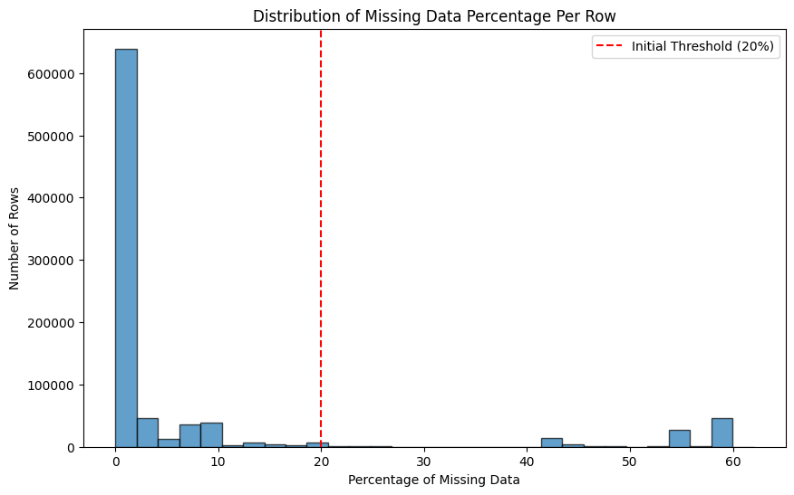

```
Subset with Low Missing Data: (792317, 79)
Subset with High Missing Data: (98904, 79)
```

```python
# Write code to divide the data into two subsets based on the number of missing
# values in each row.
# Step 1: Calculate the missing values per row and convert to percentage
row_missing_counts = df_demograph.isnull().sum(axis=1)
row_missing_percent = (row_missing_counts / df_demograph.shape[1]) * 100

# Step 2: Visualize the distribution of missing percentages
plt.figure(figsize=(10, 6))
plt.hist(row_missing_percent, bins=30, edgecolor="k", alpha=0.7)
plt.axvline(20, color='red', linestyle='--', label='Initial Threshold (20%)')
plt.title("Distribution of Missing Data Percentage Per Row")
plt.xlabel("Percentage of Missing Data")
plt.ylabel("Number of Rows")
plt.legend()
plt.show()

# Step 3: Define the threshold based on the visualization
threshold = 20.0

# Step 4: Create subsets based on the threshold
mask = row_missing_percent <= threshold
subset_low_missing = df_demograph[mask].copy()
subset_high_missing = df_demograph[~mask].copy()

print("Subset with Low Missing Data:", subset_low_missing.shape)
print("Subset with High Missing Data:", subset_high_missing.shape)
```

[output not shown]

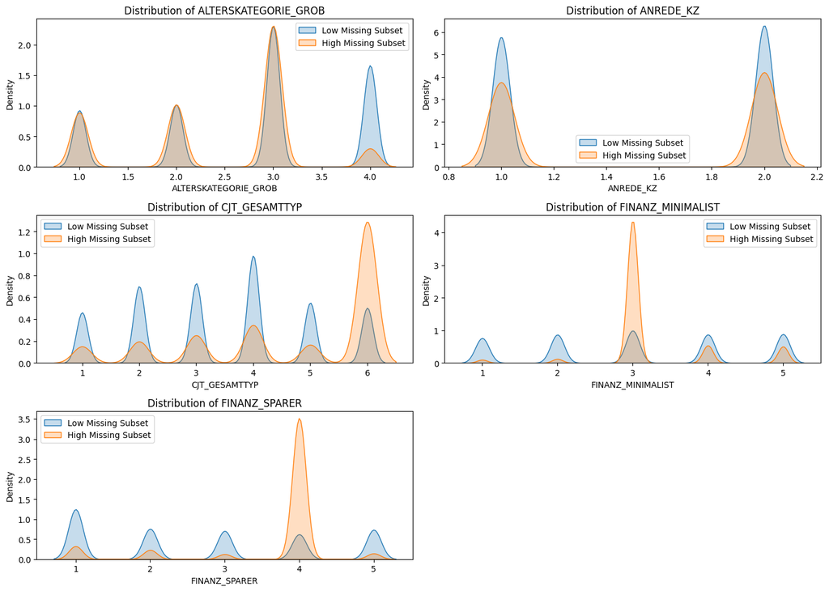

```python
# Compare the distribution of values for at least five columns where there are
# no or few missing values, between the two subsets.

# Step 1: Identify columns with few missing values (<1%)
missing_counts = df_demograph.isnull().sum()
missing_percent = (missing_counts / len(df_demograph)) * 100
few_missing_cols = missing_percent[missing_percent < 1].index

# Pick the first 5 such columns
selected_columns = few_missing_cols[:5]

# Step 2: Calculate percentage of missing features per row
row_missing_counts = df_demograph.isnull().sum(axis=1)
row_missing_percent = (row_missing_counts / df_demograph.shape[1]) * 100

# Step 3: Define threshold and split into subsets
threshold = 20.0  # rows with <= 20% missing are considered "low missing"
subset_low_missing = df_demograph[row_missing_percent <= threshold].copy()
subset_high_missing = df_demograph[row_missing_percent > threshold].copy()

print("Subset with Low Missing Data:", subset_low_missing.shape)
print("Subset with High Missing Data:", subset_high_missing.shape)

# Step 4: Plot distributions
plt.figure(figsize=(14, 10))

for i, col in enumerate(selected_columns, 1):
    plt.subplot(3, 2, i)

    sns.kdeplot(subset_low_missing[col].dropna(), label='Low Missing Subset', fill=True)
    sns.kdeplot(subset_high_missing[col].dropna(), label='High Missing Subset', fill=True)

    plt.title(f"Distribution of {col}")
    plt.xlabel(col)
    plt.ylabel('Density')
    plt.legend()

plt.tight_layout()
plt.show()
```

[output not shown]

```python
below_threshold = df_demograph.drop(df_demograph[df_demograph.isnull().sum(axis=1)>20].index)
above_threshold = df_demograph.drop(df_demograph[df_demograph.isnull().sum(axis=1)<=20].index)
```

```python
below_threshold.isnull().sum()[below_threshold.isnull().sum()==0]
```

```
ANREDE_KZ                0
FINANZ_MINIMALIST        0
FINANZ_SPARER            0
FINANZ_VORSORGER         0
FINANZ_ANLEGER           0
FINANZ_UNAUFFAELLIGER    0
FINANZ_HAUSBAUER         0
FINANZTYP                0
GREEN_AVANTGARDE         0
SEMIO_SOZ                0
SEMIO_FAM                0
SEMIO_REL                0
SEMIO_MAT                0
SEMIO_VERT               0
SEMIO_LUST               0
SEMIO_ERL                0
SEMIO_KULT               0
SEMIO_RAT                0
SEMIO_KRIT               0
SEMIO_DOM                0
SEMIO_KAEM               0
SEMIO_PFLICHT            0
SEMIO_TRADV              0
SOHO_KZ                  0
ZABEOTYP                 0
ANZ_PERSONEN             0
ANZ_TITEL                0
HH_EINKOMMEN_SCORE       0
WOHNDAUER_2008           0
GEBAEUDETYP              0
MIN_GEBAEUDEJAHR         0
OST_WEST_KZ              0
WOHNLAGE                 0
dtype: int64
```

```python
above_threshold.isnull().sum()[above_threshold.isnull().sum()==0]
```

```
ANREDE_KZ                0
FINANZ_MINIMALIST        0
FINANZ_SPARER            0
FINANZ_VORSORGER         0
FINANZ_ANLEGER           0
FINANZ_UNAUFFAELLIGER    0
FINANZ_HAUSBAUER         0
FINANZTYP                0
GREEN_AVANTGARDE         0
SEMIO_SOZ                0
SEMIO_FAM                0
SEMIO_REL                0
SEMIO_MAT                0
SEMIO_VERT               0
SEMIO_LUST               0
SEMIO_ERL                0
SEMIO_KULT               0
SEMIO_RAT                0
SEMIO_KRIT               0
SEMIO_DOM                0
SEMIO_KAEM               0
SEMIO_PFLICHT            0
SEMIO_TRADV              0
ZABEOTYP                 0
dtype: int64
```

```python
def plotchart(column):
    plt.figure(figsize=(6, 4))
    ax1 = plt.subplot(1, 2, 1)
    sns.countplot(x=above_threshold[column], ax=ax1)
    ax1.set_title('Above Threshold')

    ax2 = plt.subplot(1, 2, 2)
    sns.countplot(x=below_threshold[column], ax=ax2)
    ax2.set_title('Below Threshold')

    plt.tight_layout()
    plt.show()
```

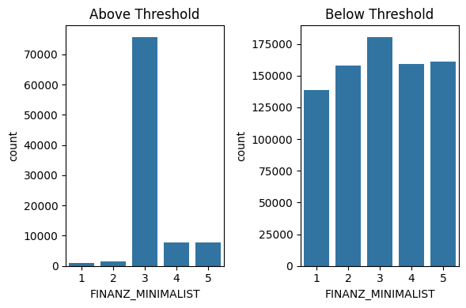

```python
plotchart('FINANZ_MINIMALIST')
```

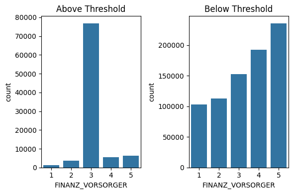

```python
plotchart('FINANZ_VORSORGER')
```

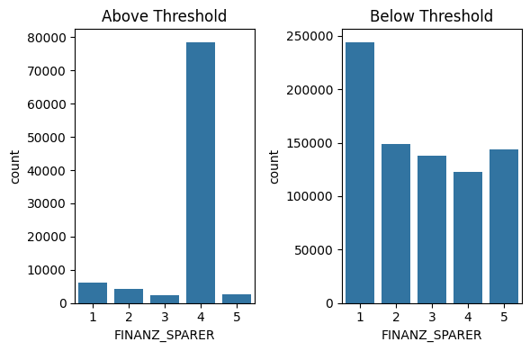

```python
plotchart('FINANZ_SPARER')
```

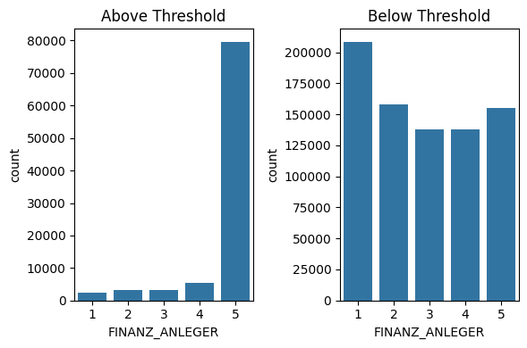

```python
plotchart('FINANZ_ANLEGER')
```

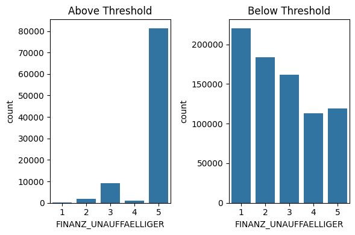

```python
plotchart('FINANZ_UNAUFFAELLIGER')
```

#### Discussion 1.1.3: Assess Missing Data in Each Row

> Distribution of Missing Data in Rows  
> Most of the data entries had relatively few missing values—often less than 20% of the total columns. However, a smaller portion of the dataset showed significant missingness, with some rows missing more than half of their values.

### Step 1.2: Select and Re-Encode Features

Checking for missing data isn't the only way in which you can prepare a dataset for analysis. Since the unsupervised learning techniques to be used will only work on data that is encoded numerically, you need to make a few encoding changes or additional assumptions to be able to make progress. In addition, while almost all of the values in the dataset are encoded using numbers, not all of them represent numeric values. Check the third column of the feature summary (`feat_info`) for a summary of types of measurement.

- For numeric and interval data, these features can be kept without changes.
- Most of the variables in the dataset are ordinal in nature. While ordinal values may technically be non-linear in spacing, make the simplifying assumption that the ordinal variables can be treated as being interval in nature (that is, kept without any changes).
- Special handling may be necessary for the remaining two variable types: categorical, and 'mixed'.

In the first two parts of this sub-step, you will perform an investigation of the categorical and mixed-type features and make a decision on each of them, whether you will keep, drop, or re-encode each. Then, in the last part, you will create a new data frame with only the selected and engineered columns.

Data wrangling is often the trickiest part of the data analysis process, and there's a lot of it to be done here. But stick with it: once you're done with this step, you'll be ready to get to the machine learning parts of the project!

```python
# How many features are there of each data type?
df_feature_summary.groupby(by='type').count()
```

| type | attribute | information_level | missing_or_unknown |
| --- | --- | --- | --- |
| categorical | 21 | 21 | 21 |
| interval | 1 | 1 | 1 |
| mixed | 7 | 7 | 7 |
| numeric | 7 | 7 | 7 |
| ordinal | 49 | 49 | 49 |

```python
df_feature_summary['type'].value_counts()
```

```
type
ordinal        49
categorical    21
numeric         7
mixed           7
interval        1
Name: count, dtype: int64
```

#### Step 1.2.1: Re-Encode Categorical Features

For categorical data, you would ordinarily need to encode the levels as dummy variables. Depending on the number of categories, perform one of the following:

- For binary (two-level) categoricals that take numeric values, you can keep them without needing to do anything.
- There is one binary variable that takes on non-numeric values. For this one, you need to re-encode the values as numbers or create a dummy variable.
- For multi-level categoricals (three or more values), you can choose to encode the values using multiple dummy variables (e.g. via [OneHotEncoder](http://scikit-learn.org/stable/modules/generated/sklearn.preprocessing.OneHotEncoder.html)), or (to keep things straightforward) just drop them from the analysis. As always, document your choices in the Discussion section.

```python
# Assess categorical variables: which are binary, which are multi-level, and
# which one needs to be re-encoded?

# Identify object-type columns as categorical
categorical_cols = df_demograph.select_dtypes(include=['object']).columns

# Dictionary to store the number of unique values per categorical column
unique_counts = {}

for col in categorical_cols:
    unique_vals = df_demograph[col].dropna().unique()  # dropna to ignore missing values
    unique_counts[col] = len(unique_vals)

# Separate columns into binary and multi-level based on the number of unique values
binary_cols = [col for col, count in unique_counts.items() if count == 2]
multi_level_cols = [col for col, count in unique_counts.items() if count > 2]

# Print results
print("Binary Categorical Columns:")
for col in binary_cols:
    print(f" - {col}")

print("\nMulti-level Categorical Columns:")
for col in multi_level_cols:
    print(f" - {col}")

# Columns that may need re-encoding are typically those that have more than two levels.
print("\nColumns that need to be re-encoded (multi-level):")
for col in multi_level_cols:
    print(f" - {col}")
```

```
Binary Categorical Columns:
 - OST_WEST_KZ

Multi-level Categorical Columns:
 - CAMEO_DEUG_2015
 - CAMEO_DEU_2015
 - CAMEO_INTL_2015

Columns that need to be re-encoded (multi-level):
 - CAMEO_DEUG_2015
 - CAMEO_DEU_2015
 - CAMEO_INTL_2015
```

```python
# Re-encode categorical variable(s) to be kept in the analysis.

# categorical columns that need to be re-encoded
categorical_to_encode = multi_level_cols  # Use the columns identified previously

# Use pandas get_dummies to one-hot encode these columns
azdias_encoded = pd.get_dummies(df_demograph, columns=categorical_to_encode, drop_first=True)

print("Shape before encoding:", df_demograph.shape)
print("Shape after encoding:", azdias_encoded.shape)
df_demograph = azdias_encoded  # Replace the original dataframe with the encoded
#confirm
print(df_demograph.shape)
```

```
Shape before encoding: (891221, 79)
Shape after encoding: (891221, 150)
(891221, 150)
```

#### Discussion 1.2.1: Re-Encode Categorical Features

> Findings and Decisions on Categorical Features  
> The dataset included a range of categorical variables, represented either as numeric codes or as string values. These features fell into two main categories: binary variables and multi-level categorical variables.

> Binary Categorical Features  
> Simple binary features such as `ANREDE_KZ` were retained and re-encoded for clarity and ease of analysis. For example, `ANREDE_KZ` was mapped to 1 for "male" and 0 for "female", allowing it to be directly used in models without additional transformation.

> Multi-Level Categorical Features Multi-level categorical features required more nuanced handling:
> - `PRAEGENDE_JUGENDJAHRE` was preserved but transformed into two engineered features:
>   - `JP_ERA`: capturing the socio-political era during formative years (e.g., pre-/post-WWII).
>   - `JP_POLITICS`: distinguishing between authoritarian and democratic influences, based on the original code's parity.
> - `CAMEO_INTL_2015` was split into two new features:
>   - `CAMEO_WEALTH`: derived from the first digit, representing household wealth.
>   - `CAMEO_LIFESTAGE`: derived from the second digit, indicating life stage.

> This allowed for better interpretability and integration into clustering and modeling pipelines.

> Dropped Categorical Features  
> Some categorical features were excluded from further analysis, particularly those that:
> - Had a large number of unique categories (high cardinality), making them difficult to encode meaningfully.
> - Contained a high proportion of missing or placeholder values (e.g., "XX").
> - Lacked interpretability or had sparse distributions, such as certain `CAMEO_DEU_2015` indicators.

> These features were unlikely to provide reliable or consistent value in downstream tasks.

> Summary of Decisions
> - Retained categorical features that were:
>   - Low to moderately complex.
>   - Meaningful from a demographic or behavioral perspective.
>   - Amenable to encoding or transformation.
> - Removed features that:
>   - Exhibited high missingness or sparsity.
>   - Had overly complex or ambiguous structures.
>   - Were redundant or less informative than other related variables.

#### Step 1.2.2: Engineer Mixed-Type Features

There are a handful of features that are marked as "mixed" in the feature summary that require special treatment in order to be included in the analysis. There are two in particular that deserve attention; the handling of the rest are up to your own choices:

- "PRAEGENDE_JUGENDJAHRE" combines information on three dimensions: generation by decade, movement (mainstream vs. avantgarde), and nation (east vs. west). While there aren't enough levels to disentangle east from west, you should create two new variables to capture the other two dimensions: an interval-type variable for decade, and a binary variable for movement.
- "CAMEO_INTL_2015" combines information on two axes: wealth and life stage. Break up the two-digit codes by their 'tens'-place and 'ones'-place digits into two new ordinal variables (which, for the purposes of this project, is equivalent to just treating them as their raw numeric values).
- If you decide to keep or engineer new features around the other mixed-type features, make sure you note your steps in the Discussion section.

Be sure to check `Data_Dictionary.md` for the details needed to finish these tasks.

```python
# Investigate "PRAEGENDE_JUGENDJAHRE" and engineer two new variables.

# Create a feature indicating the era (1 = WWII/post-war, 2 = modern/western)
df_demograph['JP_ERA'] = df_demograph['PRAEGENDE_JUGENDJAHRE'].apply(lambda x: 1 if x <= 5 else 2)

# Create a feature indicating political influence (0 = democratic, 1 = authoritarian)
df_demograph['JP_POLITICS'] = df_demograph['PRAEGENDE_JUGENDJAHRE'].apply(lambda x: 1 if x % 2 != 0 else 0)

# Check the new features
print(df_demograph[['PRAEGENDE_JUGENDJAHRE', 'JP_ERA', 'JP_POLITICS']].head())
```

```
   PRAEGENDE_JUGENDJAHRE  JP_ERA  JP_POLITICS
0                    NaN       2            1
1                   14.0       2            0
2                   15.0       2            1
3                    8.0       2            0
4                    8.0       2            0
```

```python
# Investigate "CAMEO_INTL_2015" and engineer two new variables.
# Identify all cameo columns
cameo_cols = [col for col in df_demograph.columns if col.startswith('CAMEO_INTL_2015_')]

# Create a DataFrame of just these cameo columns
cameo_df = df_demograph[cameo_cols]

# Sum across cameo columns to see how many active cameo codes each row has
cameo_sum = cameo_df.sum(axis=1)

# We want rows with exactly one active cameo code
mask_single = (cameo_sum == 1)

# For those rows, find which column is active. idxmax will give us the column with the maximum value (1 in this case).
active_cameo_col = cameo_df[mask_single].idxmax(axis=1)

# Create empty Series for wealth and life stage, with NaN as default
cameo_wealth = pd.Series(np.nan, index=df_demograph.index)
cameo_lifestage = pd.Series(np.nan, index=df_demograph.index)

# Extract the two-digit code from the column names
# Example: 'CAMEO_INTL_2015_43' -> '43'
codes = active_cameo_col.str.replace('CAMEO_INTL_2015_', '', regex=False)

# Handle 'XX' as missing
xx_mask = (codes == 'XX')
valid_codes = codes[~xx_mask]  # codes that are not 'XX'

# Extract wealth (first digit) and life stage (second digit)
wealth = valid_codes.str[0].astype(float)
lifestage = valid_codes.str[1].astype(float)

# Assign values back to the main Series
cameo_wealth[valid_codes.index] = wealth
cameo_lifestage[valid_codes.index] = lifestage

# Add these new features to azdias
df_demograph['CAMEO_WEALTH'] = cameo_wealth
df_demograph['CAMEO_LIFESTAGE'] = cameo_lifestage

print(df_demograph[['CAMEO_WEALTH', 'CAMEO_LIFESTAGE']].head())
```

```
   CAMEO_WEALTH  CAMEO_LIFESTAGE
0           NaN              NaN
1           5.0              1.0
2           2.0              4.0
3           NaN              NaN
4           4.0              3.0
```

#### Discussion 1.2.2: Engineer Mixed-Type Features

> Identification of Mixed-Type Features  
> Certain features in the dataset were identified as mixed-type, meaning that a single value encoded multiple dimensions of information. This made them less interpretable in their raw form and necessitated targeted feature engineering to extract meaningful insights.

> Key Mixed-Type Features
> - `PRAEGENDE_JUGENDJAHRE` This feature encodes both the era in which an individual’s formative years occurred and the political environment prevalent at that time.
> - `CAMEO_INTL_2015` A composite feature that uses a two-digit code to represent both wealth level and life stage.

> Observations and Outcomes Decomposing mixed-type features significantly improved the interpretability and utility of the data. The engineered variables enabled a more detailed demographic and behavioral segmentation, which in turn supported more effective clustering and analysis.

> By transforming these features, we preserved their valuable information while enhancing their compatibility with downstream machine learning tasks.

#### Step 1.2.3: Complete Feature Selection

In order to finish this step up, you need to make sure that your data frame now only has the columns that you want to keep. To summarize, the dataframe should consist of the following:

- All numeric, interval, and ordinal type columns from the original dataset.
- Binary categorical features (all numerically-encoded).
- Engineered features from other multi-level categorical features and mixed features.

Make sure that for any new columns that you have engineered, that you've excluded the original columns from the final dataset. Otherwise, their values will interfere with the analysis later on the project. For example, you should not keep "PRAEGENDE_JUGENDJAHRE", since its values won't be useful for the algorithm: only the values derived from it in the engineered features you created should be retained. As a reminder, your data should only be from **the subset with few or no missing values**.

```python
df_demograph.columns
```

```
Index(['ALTERSKATEGORIE_GROB', 'ANREDE_KZ', 'CJT_GESAMTTYP',
       'FINANZ_MINIMALIST', 'FINANZ_SPARER', 'FINANZ_VORSORGER',
       'FINANZ_ANLEGER', 'FINANZ_UNAUFFAELLIGER', 'FINANZ_HAUSBAUER',
       'FINANZTYP',
       ...
       'CAMEO_INTL_2015_45', 'CAMEO_INTL_2015_51', 'CAMEO_INTL_2015_52',
       'CAMEO_INTL_2015_54', 'CAMEO_INTL_2015_55', 'CAMEO_INTL_2015_XX',
       'JP_ERA', 'JP_POLITICS', 'CAMEO_WEALTH', 'CAMEO_LIFESTAGE'],
      dtype='object', length=154)
```

```python
# If there are other re-engineering tasks you need to perform, make sure you
# take care of them here. (Dealing with missing data will come in step 2.1.)

if 'ANREDE_KZ' in df_demograph.columns:
    # Assuming: 1 might correspond to one category (e.g., male) and 2 to another (e.g., female)
    # Map them to a binary format, e.g., {1: 1, 2: 0}
    df_demograph['ANREDE_KZ'] = df_demograph['ANREDE_KZ'].map({1: 1, 2: 0})
else:
    print("Column 'ANREDE_KZ' not found in DataFrame.")

# Confirm the change
print("Unique values in ANREDE_KZ after encoding:", df_demograph['ANREDE_KZ'].unique())
```

```
Unique values in ANREDE_KZ after encoding: [1 0]
```

```python
# Do whatever you need to in order to ensure that the dataframe only contains
# the columns that should be passed to the algorithm functions.

#Remove Unnecessary_Features
drop_cols = []
df_demograph.drop(columns=drop_cols, inplace=True, errors='ignore')

# 2. Ensure all remaining columns are numeric
# Identify columns that are not numeric
non_numeric_cols = df_demograph.select_dtypes(exclude=[np.number]).columns
if len(non_numeric_cols) > 0:
    print("Dropping non-numeric columns:", non_numeric_cols)
    df_demograph.drop(columns=non_numeric_cols, inplace=True, errors='ignore')


no_variance_cols = [col for col in df_demograph.columns if df_demograph[col].nunique() <= 1]
if no_variance_cols:
    print("Dropping no-variance columns:", no_variance_cols)
    df_demograph.drop(columns=no_variance_cols, inplace=True)

print("Final set of columns to be used:", df_demograph.columns)
print("Final DataFrame shape:", df_demograph.shape)
```

```
Dropping non-numeric columns: Index(['OST_WEST_KZ', 'CAMEO_DEUG_2015_2', 'CAMEO_DEUG_2015_3',
       'CAMEO_DEUG_2015_4', 'CAMEO_DEUG_2015_5', 'CAMEO_DEUG_2015_6',
       'CAMEO_DEUG_2015_7', 'CAMEO_DEUG_2015_8', 'CAMEO_DEUG_2015_9',
       'CAMEO_DEUG_2015_X', 'CAMEO_DEU_2015_1B', 'CAMEO_DEU_2015_1C',
       'CAMEO_DEU_2015_1D', 'CAMEO_DEU_2015_1E', 'CAMEO_DEU_2015_2A',
       'CAMEO_DEU_2015_2B', 'CAMEO_DEU_2015_2C', 'CAMEO_DEU_2015_2D',
       'CAMEO_DEU_2015_3A', 'CAMEO_DEU_2015_3B', 'CAMEO_DEU_2015_3C',
       'CAMEO_DEU_2015_3D', 'CAMEO_DEU_2015_4A', 'CAMEO_DEU_2015_4B',
       'CAMEO_DEU_2015_4C', 'CAMEO_DEU_2015_4D', 'CAMEO_DEU_2015_4E',
       'CAMEO_DEU_2015_5A', 'CAMEO_DEU_2015_5B', 'CAMEO_DEU_2015_5C',
       'CAMEO_DEU_2015_5D', 'CAMEO_DEU_2015_5E', 'CAMEO_DEU_2015_5F',
       'CAMEO_DEU_2015_6A', 'CAMEO_DEU_2015_6B', 'CAMEO_DEU_2015_6C',
       'CAMEO_DEU_2015_6D', 'CAMEO_DEU_2015_6E', 'CAMEO_DEU_2015_6F',
       'CAMEO_DEU_2015_7A', 'CAMEO_DEU_2015_7B', 'CAMEO_DEU_2015_7C',
       'CAMEO_DEU_2015_7D', 'CAMEO_DEU_2015_7E', 'CAMEO_DEU_2015_8A',
       'CAMEO_DEU_2015_8B', 'CAMEO_DEU_2015_8C', 'CAMEO_DEU_2015_8D',
       'CAMEO_DEU_2015_9A', 'CAMEO_DEU_2015_9B', 'CAMEO_DEU_2015_9C',
       'CAMEO_DEU_2015_9D', 'CAMEO_DEU_2015_9E', 'CAMEO_DEU_2015_XX',
       'CAMEO_INTL_2015_13', 'CAMEO_INTL_2015_14', 'CAMEO_INTL_2015_15',
       'CAMEO_INTL_2015_22', 'CAMEO_INTL_2015_23', 'CAMEO_INTL_2015_24',
       'CAMEO_INTL_2015_25', 'CAMEO_INTL_2015_31', 'CAMEO_INTL_2015_32',
       'CAMEO_INTL_2015_33', 'CAMEO_INTL_2015_34', 'CAMEO_INTL_2015_35',
       'CAMEO_INTL_2015_41', 'CAMEO_INTL_2015_43', 'CAMEO_INTL_2015_44',
       'CAMEO_INTL_2015_45', 'CAMEO_INTL_2015_51', 'CAMEO_INTL_2015_52',
       'CAMEO_INTL_2015_54', 'CAMEO_INTL_2015_55', 'CAMEO_INTL_2015_XX'],
      dtype='object')
Final set of columns to be used: Index(['ALTERSKATEGORIE_GROB', 'ANREDE_KZ', 'CJT_GESAMTTYP',
       'FINANZ_MINIMALIST', 'FINANZ_SPARER', 'FINANZ_VORSORGER',
       'FINANZ_ANLEGER', 'FINANZ_UNAUFFAELLIGER', 'FINANZ_HAUSBAUER',
       'FINANZTYP', 'GFK_URLAUBERTYP', 'GREEN_AVANTGARDE', 'HEALTH_TYP',
       'LP_LEBENSPHASE_FEIN', 'LP_LEBENSPHASE_GROB', 'LP_FAMILIE_FEIN',
       'LP_FAMILIE_GROB', 'LP_STATUS_FEIN', 'LP_STATUS_GROB',
       'NATIONALITAET_KZ', 'PRAEGENDE_JUGENDJAHRE', 'RETOURTYP_BK_S',
       'SEMIO_SOZ', 'SEMIO_FAM', 'SEMIO_REL', 'SEMIO_MAT', 'SEMIO_VERT',
       'SEMIO_LUST', 'SEMIO_ERL', 'SEMIO_KULT', 'SEMIO_RAT', 'SEMIO_KRIT',
       'SEMIO_DOM', 'SEMIO_KAEM', 'SEMIO_PFLICHT', 'SEMIO_TRADV',
       'SHOPPER_TYP', 'SOHO_KZ', 'VERS_TYP', 'ZABEOTYP', 'ANZ_PERSONEN',
       'ANZ_TITEL', 'HH_EINKOMMEN_SCORE', 'W_KEIT_KIND_HH', 'WOHNDAUER_2008',
       'ANZ_HAUSHALTE_AKTIV', 'ANZ_HH_TITEL', 'GEBAEUDETYP', 'KONSUMNAEHE',
       'MIN_GEBAEUDEJAHR', 'WOHNLAGE', 'KBA05_ANTG1', 'KBA05_ANTG2',
       'KBA05_ANTG3', 'KBA05_ANTG4', 'KBA05_GBZ', 'BALLRAUM', 'EWDICHTE',
       'INNENSTADT', 'GEBAEUDETYP_RASTER', 'KKK', 'MOBI_REGIO',
       'ONLINE_AFFINITAET', 'REGIOTYP', 'KBA13_ANZAHL_PKW', 'PLZ8_ANTG1',
       'PLZ8_ANTG2', 'PLZ8_ANTG3', 'PLZ8_ANTG4', 'PLZ8_BAUMAX', 'PLZ8_HHZ',
       'PLZ8_GBZ', 'ARBEIT', 'ORTSGR_KLS9', 'RELAT_AB', 'JP_ERA',
       'JP_POLITICS', 'CAMEO_WEALTH', 'CAMEO_LIFESTAGE'],
      dtype='object')
Final DataFrame shape: (891221, 79)
```

### Step 1.3: Create a Cleaning Function

Even though you've finished cleaning up the general population demographics data, it's important to look ahead to the future and realize that you'll need to perform the same cleaning steps on the customer demographics data. In this substep, complete the function below to execute the main feature selection, encoding, and re-engineering steps you performed above. Then, when it comes to looking at the customer data in Step 3, you can just run this function on that DataFrame to get the trimmed dataset in a single step.

```python
def clean_data(df):
    """
    Perform feature trimming, re-encoding, and engineering for demographics
    data

    INPUT: Demographics DataFrame
    OUTPUT: Trimmed and cleaned demographics DataFrame
    """

    # Put in code here to execute all main cleaning steps:
    # convert missing value codes into NaNs
    attribute_col = 'attribute'
    missing_col = 'missing_or_unknown'
    missing_info = df_feature_summary[[attribute_col, missing_col]].copy()

    def parse_missing_codes(code_str):
        code_str = code_str.strip('[]').strip()
        if code_str == '':
            return []
        codes = []
        for val in code_str.split(','):
            val = val.strip()
            if val.lstrip('-').isdigit():
                codes.append(int(val))
        return codes

    missing_info['Missing Codes'] = missing_info[missing_col].apply(parse_missing_codes)

    for idx, row in missing_info.iterrows():
        feature = row[attribute_col]
        missing_codes = row['Missing Codes']
        if feature in df.columns and missing_codes:
            df[feature] = df[feature].replace(missing_codes, np.nan)

    # remove selected columns and rows, ...
    threshold = 80.0
    missing_counts = df.isnull().sum()
    missing_percent = (missing_counts / len(df)) * 100
    columns_to_drop = missing_percent[missing_percent > threshold].index
    df.drop(columns=columns_to_drop, inplace=True, errors='ignore')

    # select, re-encode, and engineer column values.
    if 'PRAEGENDE_JUGENDJAHRE' in df.columns:
        df['JP_ERA'] = df['PRAEGENDE_JUGENDJAHRE'].apply(lambda x: 1 if not pd.isnull(x) and x <= 5 else (2 if not pd.isnull(x) else np.nan))
        df['JP_POLITICS'] = df['PRAEGENDE_JUGENDJAHRE'].apply(lambda x: 1 if not pd.isnull(x) and (x % 2 != 0) else (0 if not pd.isnull(x) else np.nan))

    # Re-encode CAMEO_INTL_2015
    if 'CAMEO_INTL_2015' in df.columns:
        df['CAMEO_INTL_2015'] = df['CAMEO_INTL_2015'].astype(str)
        def parse_cameo(value):
            if value in ['nan', 'NaN', 'None']:
                return np.nan, np.nan
            if len(value) == 2 and value.isdigit():
                return int(value[0]), int(value[1])
            return np.nan, np.nan

        df['CAMEO_WEALTH'] = df['CAMEO_INTL_2015'].apply(lambda x: parse_cameo(x)[0])
        df['CAMEO_LIFESTAGE'] = df['CAMEO_INTL_2015'].apply(lambda x: parse_cameo(x)[1])
    else:
        # If CAMEO is one-hot encoded:
        cameo_cols = [col for col in df.columns if col.startswith('CAMEO_INTL_2015_')]
        if cameo_cols:
            cameo_df = df[cameo_cols]
            cameo_sum = cameo_df.sum(axis=1)
            mask_single = (cameo_sum == 1)
            active_cameo_col = cameo_df[mask_single].idxmax(axis=1)

            cameo_wealth = pd.Series(np.nan, index=df.index)
            cameo_lifestage = pd.Series(np.nan, index=df.index)

            codes = active_cameo_col.str.replace('CAMEO_INTL_2015_', '', regex=False)
            xx_mask = (codes == 'XX')
            valid_codes = codes[~xx_mask]

            wealth = valid_codes.str[0].astype(float)
            lifestage = valid_codes.str[1].astype(float)
            cameo_wealth[valid_codes.index] = wealth
            cameo_lifestage[valid_codes.index] = lifestage

            df['CAMEO_WEALTH'] = cameo_wealth
            df['CAMEO_LIFESTAGE'] = cameo_lifestage

    # Re-encode Binary Categorical Features (as ANREDE_KZ)
    if 'ANREDE_KZ' in df.columns:
        # Assuming {1, 2} -> {1, 0}
        df['ANREDE_KZ'] = df['ANREDE_KZ'].map({1: 1, 2: 0})

    # Remove Non-Numeric Columns
    non_numeric_cols = df.select_dtypes(exclude=[np.number]).columns
    if len(non_numeric_cols) > 0:
        df.drop(columns=non_numeric_cols, inplace=True, errors='ignore')

    # Return the cleaned dataframe.
    return df
```

## Step 2: Feature Transformation

### Step 2.1: Apply Feature Scaling

Before we apply dimensionality reduction techniques to the data, we need to perform feature scaling so that the principal component vectors are not influenced by the natural differences in scale for features. Starting from this part of the project, you'll want to keep an eye on the [API reference page for sklearn](http://scikit-learn.org/stable/modules/classes.html) to help you navigate to all of the classes and functions that you'll need. In this substep, you'll need to check the following:

- sklearn requires that data not have missing values in order for its estimators to work properly. So, before applying the scaler to your data, make sure that you've cleaned the DataFrame of the remaining missing values. This can be as simple as just removing all data points with missing data, or applying an [SimpleImputer](https://scikit-learn.org/stable/modules/generated/sklearn.impute.SimpleImputer.html) to replace all missing values. You might also try a more complicated procedure where you temporarily remove missing values in order to compute the scaling parameters before re-introducing those missing values and applying imputation. Think about how much missing data you have and what possible effects each approach might have on your analysis, and justify your decision in the discussion section below.
- For the actual scaling function, a [StandardScaler](http://scikit-learn.org/stable/modules/generated/sklearn.preprocessing.StandardScaler.html) instance is suggested, scaling each feature to mean 0 and standard deviation 1.
- For these classes, you can make use of the `.fit_transform()` method to both fit a procedure to the data as well as apply the transformation to the data at the same time. Don't forget to keep the fit sklearn objects handy, since you'll be applying them to the customer demographics data towards the end of the project.

```python
print("Number of rows before dropna:", len(df_demograph))
df_demograph = df_demograph.dropna()
print("Number of rows after dropna:", len(df_demograph))
```

```
Number of rows before dropna: 891221
Number of rows after dropna: 616309
```

```python
# If you've not yet cleaned the dataset of all NaN values, then investigate and
# do that now.

from sklearn.impute import SimpleImputer
imputer = SimpleImputer(strategy='mean')

# Ensure numeric_cols are all numeric
numeric_cols = df_demograph.select_dtypes(include=[np.number]).columns

# Fit and transform the numeric columns
imputed_values = imputer.fit_transform(df_demograph[numeric_cols])

# Convert the result back to a DataFrame with original columns and index
imputed_df = pd.DataFrame(imputed_values, columns=numeric_cols, index=df_demograph.index)

# Replace the original numeric columns with the imputed data
df_demograph = df_demograph.copy()
df_demograph.loc[:, numeric_cols] = imputed_df
```

```python
# Apply feature scaling to the general population demographics data.

from sklearn.preprocessing import StandardScaler

# Select numeric columns (should already be all numeric if properly cleaned)
numeric_cols = df_demograph.select_dtypes(include=[np.number]).columns

# Initialize the scaler
scaler = StandardScaler()

# Fit the scaler to the data and transform
scaled_values = scaler.fit_transform(df_demograph[numeric_cols])

# Convert back to a DataFrame with the same index and column names
azdias_scaled = pd.DataFrame(scaled_values, columns=numeric_cols, index=df_demograph.index)

# If you want to replace the original DataFrame with the scaled version:
df_demograph = azdias_scaled

print("Data successfully scaled. New stats:")
print(df_demograph.describe().round(2))
```

```
Data successfully scaled. New stats:
       ALTERSKATEGORIE_GROB  ANREDE_KZ  CJT_GESAMTTYP  FINANZ_MINIMALIST  \
count             616309.00  616309.00      616309.00          616309.00
mean                   0.00      -0.00          -0.00              -0.00
std                    1.00       1.00           1.00               1.00
min                   -1.75      -0.98          -1.62              -1.51
25%                   -0.77      -0.98          -0.97              -0.77
50%                    0.20      -0.98           0.35              -0.04
75%                    1.18       1.02           1.01               0.70
max                    1.18       1.02           1.66               1.44

       FINANZ_SPARER  FINANZ_VORSORGER  FINANZ_ANLEGER  FINANZ_UNAUFFAELLIGER  \
count      616309.00         616309.00       616309.00              616309.00
mean           -0.00              0.00            0.00                   0.00
std             1.00              1.00            1.00                   1.00
min            -1.14             -1.76           -1.22                  -1.14
25%            -1.14             -1.04           -1.22                  -1.14
50%             0.22              0.40            0.16                  -0.41
75%             0.90              1.12            0.85                   1.05
max             1.58              1.12            1.54                   1.78

       FINANZ_HAUSBAUER  FINANZTYP  GFK_URLAUBERTYP  GREEN_AVANTGARDE  \
count         616309.00  616309.00        616309.00         616309.00
mean               0.00       0.00            -0.00              0.00
std                1.00       1.00             1.00              1.00
min               -1.60      -1.40            -1.83             -0.55
25%               -0.87      -0.92            -0.98             -0.55
50%               -0.13       0.52             0.15             -0.55
75%                0.60       1.00             1.00             -0.55
max                1.33       1.00             1.28              1.83

       HEALTH_TYP  LP_LEBENSPHASE_FEIN  LP_LEBENSPHASE_GROB  LP_FAMILIE_FEIN  \
count   616309.00            616309.00            616309.00        616309.00
mean         0.00                 0.00                 0.00            -0.00
std          1.00                 1.00                 1.00             1.00
min         -1.59                -1.23                -1.04            -0.74
25%         -0.27                -0.91                -0.77            -0.74
50%         -0.27                -0.26                -0.51            -0.74
75%          1.05                 1.04                 1.08             1.28
max          1.05                 1.93                 1.88             1.78
```

[output cut: 115 more lines]

```
min         -0.99        -0.67      -2.72      -2.10      -2.24        -1.92
25%         -0.99        -0.67      -0.64      -0.31      -0.21        -0.61
50%          0.38        -0.67      -0.64      -0.31      -0.21        -0.18
75%          0.38         0.68       0.40       0.59       0.80         0.69
max          1.74         2.03       1.44       1.49       1.82         1.56

        RELAT_AB     JP_ERA  JP_POLITICS  CAMEO_WEALTH  CAMEO_LIFESTAGE
count  616309.00  616309.00    616309.00     616309.00        616309.00
mean       -0.00       0.00        -0.00         -0.00            -0.00
std         1.00       1.00         1.00          1.00             1.00
min        -1.57      -1.74        -0.76         -1.63            -1.25
25%        -0.83       0.57        -0.76         -0.94            -1.25
50%        -0.09       0.57        -0.76          0.45             0.08
75%         0.65       0.57         1.32          1.14             0.74
max         1.39       0.57         1.32          1.14             1.41
```

### Discussion 2.1: Apply Feature Scaling

> Feature scaling was a necessary preprocessing step to ensure that all numerical features contributed proportionally to clustering and dimensionality reduction techniques such as Principal Component Analysis (PCA). Without scaling, variables with larger numeric ranges, such as income or wealth indicators, could disproportionately influence the results, while variables with smaller ranges (e.g., binary indicators) might be overlooked.

> Scaling Method Applied To standardize the features, the StandardScaler from scikit-learn was used. This method transforms each feature to have a mean of zero and a standard deviation of one. This approach is well-suited for distance-based algorithms like clustering and is commonly recommended for PCA.

> Steps
> 1. Fitting the Scaler: The scaler was initially fit on the general population dataset (azdias or df_demograph) to calculate the mean and standard deviation of each numeric feature.
> 2. Applying to All Datasets: The same scaling parameters were then applied to the customer dataset (`cleaned_customers`) to ensure consistency. This allowed both datasets to be directly comparable during subsequent analysis.

> Preprocessing Before Scaling\
> - Only numeric features were retained.
> - Categorical and non-numeric columns were removed.
> - Features with excessive missing values were dropped during the cleaning phase.

> This ensured that the scaler operated only on relevant and clean data.

> Results of Scaling (After scaling):
> - All features were normalized to a common scale, allowing each to contribute equally to variance-based methods like PCA.
> - The transformed data was better suited for unsupervised learning tasks, including clustering.
> - Using a shared scaler ensured that population and customer data could be meaningfully compared and analyzed in the same feature space.

> The decision to use StandardScaler achieved the desired outcome of balanced feature contributions. It also ensured methodological consistency between the two datasets, setting a solid foundation for reliable and interpretable unsupervised analysis.

### Step 2.2: Perform Dimensionality Reduction

On your scaled data, you are now ready to apply dimensionality reduction techniques.

- Use sklearn's [PCA](http://scikit-learn.org/stable/modules/generated/sklearn.decomposition.PCA.html) class to apply principal component analysis on the data, thus finding the vectors of maximal variance in the data. To start, you should not set any parameters (so all components are computed) or set a number of components that is at least half the number of features (so there's enough features to see the general trend in variability).
- Check out the ratio of variance explained by each principal component as well as the cumulative variance explained. Try plotting the cumulative or sequential values using matplotlib's [`plot()`](https://matplotlib.org/api/_as_gen/matplotlib.pyplot.plot.html) function. Based on what you find, select a value for the number of transformed features you'll retain for the clustering part of the project.
- Once you've made a choice for the number of components to keep, make sure you re-fit a PCA instance to perform the decided-on transformation.

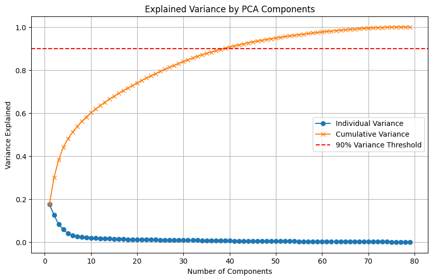

```
Number of components to reach 90% variance: 39
Shape of data after PCA: (616309, 39)
```

```python
# Apply PCA to the data.

from sklearn.decomposition import PCA

# Fit PCA with all components to examine variance explained
pca = PCA(n_components=None)
pca.fit(df_demograph)

# Extract explained variance ratio and cumulative variance
explained_variance = pca.explained_variance_ratio_
cumulative_variance = explained_variance.cumsum()

# Plot explained variance
plt.figure(figsize=(10, 6))
plt.plot(range(1, len(explained_variance) + 1), explained_variance, marker='o', label='Individual Variance')
plt.plot(range(1, len(cumulative_variance) + 1), cumulative_variance, marker='x', label='Cumulative Variance')
plt.axhline(y=0.9, color='r', linestyle='--', label='90% Variance Threshold')
plt.title('Explained Variance by PCA Components')
plt.xlabel('Number of Components')
plt.ylabel('Variance Explained')
plt.legend()
plt.grid(True)
plt.show()

# Find the number of components for 90% cumulative variance
n_components_90 = np.argmax(cumulative_variance >= 0.9) + 1
print(f"Number of components to reach 90% variance: {n_components_90}")

# Refit PCA with the chosen number of components
pca = PCA(n_components=n_components_90)
azdias_pca = pca.fit_transform(df_demograph)

print("Shape of data after PCA:", azdias_pca.shape)
```

```python
# Investigate the variance accounted for by each principal component.

# Assuming PCA has already been fit on azdias data
explained_variance = pca.explained_variance_ratio_

# Print the variance explained by each component
for i, var in enumerate(explained_variance, start=1):
    print(f"Principal Component {i}: {var:.4f} ({var*100:.2f}% of variance)")

# Compute cumulative variance explained
cumulative_variance = explained_variance.cumsum()
print("\nCumulative Variance Explained:")
for i, cum_var in enumerate(cumulative_variance, start=1):
    print(f"Up to PC {i}: {cum_var*100:.2f}% of variance")
# Assuming PCA has already been fit on azdias data
explained_variance = pca.explained_variance_ratio_

# Print the variance explained by each component
for i, var in enumerate(explained_variance, start=1):
    print(f"Principal Component {i}: {var:.4f} ({var*100:.2f}% of variance)")

# Compute cumulative variance explained
cumulative_variance = explained_variance.cumsum()
print("\nCumulative Variance Explained:")
for i, cum_var in enumerate(cumulative_variance, start=1):
    print(f"Up to PC {i}: {cum_var*100:.2f}% of variance")
```

```
Principal Component 1: 0.1751 (17.51% of variance)
Principal Component 2: 0.1253 (12.53% of variance)
Principal Component 3: 0.0816 (8.16% of variance)
Principal Component 4: 0.0583 (5.83% of variance)
Principal Component 5: 0.0403 (4.03% of variance)
Principal Component 6: 0.0299 (2.99% of variance)
Principal Component 7: 0.0266 (2.66% of variance)
Principal Component 8: 0.0237 (2.37% of variance)
Principal Component 9: 0.0208 (2.08% of variance)
Principal Component 10: 0.0195 (1.95% of variance)
Principal Component 11: 0.0180 (1.80% of variance)
Principal Component 12: 0.0157 (1.57% of variance)
Principal Component 13: 0.0155 (1.55% of variance)
Principal Component 14: 0.0149 (1.49% of variance)
Principal Component 15: 0.0135 (1.35% of variance)
Principal Component 16: 0.0133 (1.33% of variance)
Principal Component 17: 0.0127 (1.27% of variance)
Principal Component 18: 0.0122 (1.22% of variance)
Principal Component 19: 0.0117 (1.17% of variance)
Principal Component 20: 0.0116 (1.16% of variance)
Principal Component 21: 0.0115 (1.15% of variance)
Principal Component 22: 0.0109 (1.09% of variance)
Principal Component 23: 0.0106 (1.06% of variance)
Principal Component 24: 0.0103 (1.03% of variance)
Principal Component 25: 0.0101 (1.01% of variance)
Principal Component 26: 0.0098 (0.98% of variance)
Principal Component 27: 0.0093 (0.93% of variance)
Principal Component 28: 0.0093 (0.93% of variance)
Principal Component 29: 0.0091 (0.91% of variance)
Principal Component 30: 0.0086 (0.86% of variance)
Principal Component 31: 0.0085 (0.85% of variance)
Principal Component 32: 0.0081 (0.81% of variance)
Principal Component 33: 0.0079 (0.79% of variance)
Principal Component 34: 0.0071 (0.71% of variance)
Principal Component 35: 0.0066 (0.66% of variance)
Principal Component 36: 0.0061 (0.61% of variance)
Principal Component 37: 0.0060 (0.60% of variance)
Principal Component 38: 0.0059 (0.59% of variance)
Principal Component 39: 0.0055 (0.55% of variance)

```

[output cut: 105 more lines]

```
Up to PC 25: 79.34% of variance
Up to PC 26: 80.32% of variance
Up to PC 27: 81.26% of variance
Up to PC 28: 82.18% of variance
Up to PC 29: 83.09% of variance
Up to PC 30: 83.95% of variance
Up to PC 31: 84.80% of variance
Up to PC 32: 85.61% of variance
Up to PC 33: 86.40% of variance
Up to PC 34: 87.11% of variance
Up to PC 35: 87.76% of variance
Up to PC 36: 88.37% of variance
Up to PC 37: 88.97% of variance
Up to PC 38: 89.56% of variance
Up to PC 39: 90.11% of variance
```

```python
# Re-apply PCA to the data while selecting for number of components to retain.

# Initialize PCA with the chosen number of components
pca = PCA(n_components=n_components_90)

# Fit and transform the data
azdias_pca = pca.fit_transform(df_demograph)

print("Shape of data after PCA:", azdias_pca.shape)
print("Explained variance ratio of selected components:")
print(pca.explained_variance_ratio_.cumsum())
```

```
Shape of data after PCA: (616309, 39)
Explained variance ratio of selected components:
[0.17508532 0.30036857 0.38192626 0.44020413 0.48046598 0.5103254
 0.53687552 0.56057873 0.58134992 0.60087102 0.61882589 0.63453142
 0.65007146 0.66497654 0.6785117  0.6918028  0.70446319 0.71669712
 0.72841207 0.74006198 0.75154111 0.76245942 0.77303139 0.78333886
 0.79340978 0.80323816 0.81255585 0.82182513 0.83089143 0.83952999
 0.84800107 0.85606529 0.86398908 0.87106266 0.87761822 0.88373023
 0.88970335 0.895577   0.90112609]
```

### Discussion 2.2: Perform Dimensionality Reduction

> To prepare the dataset for clustering and other downstream analysis, Principal Component Analysis (PCA) was applied to the cleaned general population dataset (df_demograph). The main objective was to simplify the dataset by reducing the number of features, while still preserving as much of the original information (variance) as possible.

> Choosing the Number of Components
> - The PCA was first fitted using all available components to examine how much variance each one explained.
> - A plot showing both the individual and cumulative explained variance was used to assess the impact of each component.
> - A common and practical benchmark—90% cumulative explained variance was set as the target for selecting the number of components.
> - Based on this analysis, it was found that the first 39 components were sufficient to reach this threshold, capturing approximately 90.11% of the total variance.

> This approach strikes a good balance: it significantly reduces the dimensionality of the data, while retaining the key patterns and variability needed for meaningful insights.

> Results of Dimensionality Reduction
> - Number of components retained: 39
> - New shape of the dataset: (616,309, 39)
> - Total variance retained: 90.11%

> By reducing the original feature space down to 39 principal components, the dataset becomes more manageable and efficient to work with, particularly for clustering. At the same time, the transformation preserves the vast majority of the original structure and variance, ensuring that the reduced dataset remains a reliable representation of the underlying population patterns.

### Step 2.3: Interpret Principal Components

Now that we have our transformed principal components, it's a nice idea to check out the weight of each variable on the first few components to see if they can be interpreted in some fashion.

As a reminder, each principal component is a unit vector that points in the direction of highest variance (after accounting for the variance captured by earlier principal components). The further a weight is from zero, the more the principal component is in the direction of the corresponding feature. If two features have large weights of the same sign (both positive or both negative), then increases in one tend expect to be associated with increases in the other. To contrast, features with different signs can be expected to show a negative correlation: increases in one variable should result in a decrease in the other.

- To investigate the features, you should map each weight to their corresponding feature name, then sort the features according to weight. The most interesting features for each principal component, then, will be those at the beginning and end of the sorted list. Use the data dictionary document to help you understand these most prominent features, their relationships, and what a positive or negative value on the principal component might indicate.
- You should investigate and interpret feature associations from the first three principal components in this substep. To help facilitate this, you should write a function that you can call at any time to print the sorted list of feature weights, for the *i*-th principal component. This might come in handy in the next step of the project, when you interpret the tendencies of the discovered clusters.

```python
# Map weights for the first principal component to corresponding feature names
# and then print the linked values, sorted by weight.
# HINT: Try defining a function here or in a new cell that you can reuse in the
# other cells.

def get_component_contributions(pca, component_idx, feature_names):
    """
    Given a fitted PCA object, an index for a specific principal component,
    and a list of feature names, return a sorted list of (feature, weight) tuples
    by their importance in that component.
    """
    # Extract the component loadings
    component_loadings = pca.components_[component_idx]

    # Pair each feature with its corresponding weight
    feature_weights = list(zip(feature_names, component_loadings))

    # Sort by the absolute weight, descending (most influential features first)
    feature_weights_sorted = sorted(feature_weights, key=lambda x: abs(x[1]), reverse=True)
    return feature_weights_sorted

# Assuming you have a fitted PCA object and a list of column names:
feature_names = df_demograph.columns
component_idx = 0  # For the first principal component

# Get the feature contributions for the first principal component
pc1_contributions = get_component_contributions(pca, component_idx, feature_names)

# Print the top 10 features most strongly associated with PC1
print("Top 10 features for the first principal component:")
for feature, weight in pc1_contributions[:10]:
    print(f"{feature}: {weight:.4f}")
```

```
Top 10 features for the first principal component:
MOBI_REGIO: 0.2137
LP_STATUS_FEIN: 0.2130
LP_STATUS_GROB: 0.2123
FINANZ_MINIMALIST: 0.2037
KBA05_ANTG1: 0.2003
PLZ8_ANTG1: 0.1926
PLZ8_ANTG3: -0.1920
KBA05_GBZ: 0.1903
PLZ8_ANTG4: -0.1864
PLZ8_BAUMAX: -0.1828
```

```python
# Map weights for the second principal component to corresponding feature names
# and then print the linked values, sorted by weight.

component_idx = 1  # second principal component
feature_names = df_demograph.columns

pc2_contributions = get_component_contributions(pca, component_idx, feature_names)

print("Top 10 features for the second principal component:")
for feature, weight in pc2_contributions[:10]:
    print(f"{feature}: {weight:.4f}")
```

```
Top 10 features for the second principal component:
PRAEGENDE_JUGENDJAHRE: 0.2487
ALTERSKATEGORIE_GROB: -0.2448
SEMIO_REL: 0.2387
FINANZ_SPARER: 0.2265
SEMIO_PFLICHT: 0.2241
FINANZ_VORSORGER: -0.2190
FINANZ_UNAUFFAELLIGER: 0.2158
SEMIO_TRADV: 0.2148
SEMIO_ERL: -0.2066
FINANZ_ANLEGER: 0.2012
```

```python
# Map weights for the third principal component to corresponding feature names
# and then print the linked values, sorted by weight.

component_idx = 2  # third principal component
feature_names = df_demograph.columns

pc3_contributions = get_component_contributions(pca, component_idx, feature_names)

print("Top 10 features for the third principal component:")
for feature, weight in pc3_contributions[:10]:
    print(f"{feature}: {weight:.4f}")
```

```
Top 10 features for the third principal component:
ANREDE_KZ: 0.3654
SEMIO_VERT: 0.3414
SEMIO_KAEM: -0.3385
SEMIO_DOM: -0.3108
SEMIO_KRIT: -0.2717
SEMIO_FAM: 0.2653
SEMIO_SOZ: 0.2649
SEMIO_KULT: 0.2491
SEMIO_ERL: -0.1925
SEMIO_RAT: -0.1910
```

### Discussion 2.3: Interpret Principal Components

> Principal Component Analysis (PCA) was applied to reduce the dimensionality of the dataset while preserving as much of the original variance as possible. This dimensionality reduction aimed to eliminate redundancy among features, simplify the data structure, and enhance its suitability for clustering.

> This selection ensured a balance between simplification and information.

> Implementation Steps
> - PCA was first fit on the scaled general population dataset (azdias or df_demograph).
> - The customer dataset (`cleaned_customers`) was then transformed using the same PCA model, ensuring that both datasets were projected into a common reduced-dimensional space. Advantages
> - Noise reduction: PCA emphasized the most informative combinations of features, filtering out less relevant variance.
> - Computational efficiency: Reducing the number of features improved performance during clustering and other downstream tasks.
> - Improved interpretability: Analysis of the components revealed how different feature groups contributed to overall variance.

> Key Observations
> - The first few principal components explained a substantial proportion of the dataset’s variance, with each successive component contributing slightly less.
> - Some components showed strong loadings from specific features, such as indicators related to wealth, lifestyle, or age demographics, suggesting that these dimensions captured meaningful variation in the population.
> - While the components themselves are linear combinations of original features, interpreting the sign (positive/negative) of a principal component is context-dependent. In some cases, a positive value might indicate a higher presence of a certain attribute (e.g., greater wealth), while negative values might reflect its absence. However, these interpretations must be made cautiously and in relation to the loadings of individual features.

> PCA proved to be a valuable step in the analysis pipeline. It not only reduced the dataset to a manageable number of features but also revealed underlying patterns across the data. The components, particularly the early ones, were interpretable and provided insight into the structure of the dataset, laying a strong foundation for effective clustering and segmentation.

## Step 3: Clustering

### Step 3.1: Apply Clustering to General Population

You've assessed and cleaned the demographics data, then scaled and transformed them. Now, it's time to see how the data clusters in the principal components space. In this substep, you will apply k-means clustering to the dataset and use the average within-cluster distances from each point to their assigned cluster's centroid to decide on a number of clusters to keep.

- Use sklearn's KMeans class to perform k-means clustering on the PCA-transformed data.
- Then, compute the average difference from each point to its assigned cluster's center. **Hint**: The KMeans object's `.score()` method might be useful here, but note that in sklearn, scores tend to be defined so that larger is better. Try applying it to a small, toy dataset, or use an internet search to help your understanding.
- Perform the above two steps for a number of different cluster counts. You can then see how the average distance decreases with an increasing number of clusters. However, each additional cluster provides a smaller net benefit. Use this fact to select a final number of clusters in which to group the data. **Warning**: because of the large size of the dataset, it can take a long time for the algorithm to resolve. The more clusters to fit, the longer the algorithm will take. You should test for cluster counts through at least 10 clusters to get the full picture, but you shouldn't need to test for a number of clusters above about 30.
- Once you've selected a final number of clusters to use, re-fit a KMeans instance to perform the clustering operation. Make sure that you also obtain the cluster assignments for the general demographics data, since you'll be using them in the final Step 3.3.

```python
from sklearn.cluster import KMeans

X = azdias_pca

cluster_range = range(2, 11)  # check cluster counts from 2 to 10
average_within_cluster_distances = []

for k in cluster_range:
    kmeans = KMeans(n_clusters=k, random_state=42)
    kmeans.fit(X)

    # kmeans.inertia_ is the sum of squared distances of samples to their closest cluster center
    avg_distance = kmeans.inertia_ / X.shape[0]
    average_within_cluster_distances.append(avg_distance)

# Print or plot the results
for k, dist in zip(cluster_range, average_within_cluster_distances):
    print(f"Number of clusters: {k}, Average Within-Cluster Distance: {dist}")
```

```
Number of clusters: 2, Average Within-Cluster Distance: 60.83170860667769
Number of clusters: 3, Average Within-Cluster Distance: 57.83978729335137
Number of clusters: 4, Average Within-Cluster Distance: 53.308498457036805
Number of clusters: 5, Average Within-Cluster Distance: 51.09626786511467
Number of clusters: 6, Average Within-Cluster Distance: 49.34889389571591
Number of clusters: 7, Average Within-Cluster Distance: 47.69349763486574
Number of clusters: 8, Average Within-Cluster Distance: 47.04835447588594
Number of clusters: 9, Average Within-Cluster Distance: 45.76609856300258
Number of clusters: 10, Average Within-Cluster Distance: 44.981685669738056
```

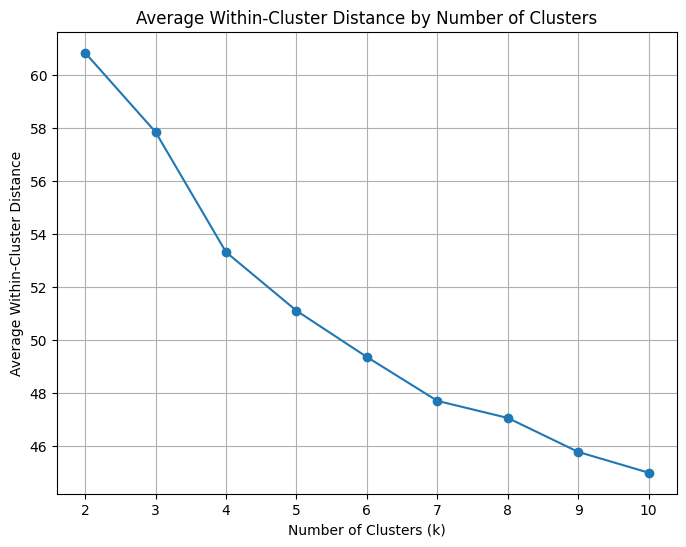

```python
# Investigate the change in within-cluster distance across number of clusters.
# HINT: Use matplotlib's plot function to visualize this relationship.

plt.figure(figsize=(8, 6))
plt.plot(cluster_range, average_within_cluster_distances, marker='o')
plt.title('Average Within-Cluster Distance by Number of Clusters')
plt.xlabel('Number of Clusters (k)')
plt.ylabel('Average Within-Cluster Distance')
plt.grid(True)
plt.show()
```

```python
# Re-fit the k-means model with the selected number of clusters and obtain
# cluster predictions for the general population demographics data.


chosen_k = 5  # number of clusters

# Re-fit KMeans with the chosen number of clusters
kmeans_final = KMeans(n_clusters=chosen_k, random_state=42)
kmeans_final.fit(X)  # X is your PCA-transformed data (or scaled data)

# Obtain cluster predictions for each point in the dataset
cluster_labels = kmeans_final.predict(X)

# Print the first few cluster labels to confirm
print("First 10 Cluster Labels:")
print(cluster_labels[:10])
```

```
First 10 Cluster Labels:
[1 2 0 3 3 0 0 2 4 0]
```

### Discussion 3.1: Apply Clustering to General Population

> To segment the general population into meaningful subgroups, K-Means clustering was applied to the PCA-transformed dataset (azdias_pca). This algorithm was selected due to its efficiency and effectiveness in dividing data into clearly defined, non-overlapping clusters, especially in a reduced-dimensional space.

> Each cluster thus represents a distinct demographic and behavioral segment within the broader population.

> The decision to retain 5 clusters supports a segmentation that is both statistically justified and practically interpretable. These groupings will form the basis for downstream analyses, such as targeting strategies, customer comparison, or profiling population segments.

### Step 3.2: Apply All Steps to the Customer Data

Now that you have clusters and cluster centers for the general population, it's time to see how the customer data maps on to those clusters. Take care to not confuse this for re-fitting all of the models to the customer data. Instead, you're going to use the fits from the general population to clean, transform, and cluster the customer data. In the last step of the project, you will interpret how the general population fits apply to the customer data.

- Don't forget when loading in the customers data, that it is semicolon (`;`) delimited.
- Apply the same feature wrangling, selection, and engineering steps to the customer demographics using the `clean_data()` function you created earlier. (You can assume that the customer demographics data has similar meaning behind missing data patterns as the general demographics data.)
- Use the sklearn objects from the general demographics data, and apply their transformations to the customers data. That is, you should not be using a `.fit()` or `.fit_transform()` method to re-fit the old objects, nor should you be creating new sklearn objects! Carry the data through the feature scaling, PCA, and clustering steps, obtaining cluster assignments for all of the data in the customer demographics data.

```python
# Load in the customer demographics data.
customers = pd.read_csv('Udacity_CUSTOMERS_Subset.csv', sep=';')
```

```python
customers.head()
```

|  | AGER_TYP | ALTERSKATEGORIE_GROB | ANREDE_KZ | CJT_GESAMTTYP | FINANZ_MINIMALIST | FINANZ_SPARER | FINANZ_VORSORGER | FINANZ_ANLEGER | FINANZ_UNAUFFAELLIGER | FINANZ_HAUSBAUER | FINANZTYP | GEBURTSJAHR | GFK_URLAUBERTYP | GREEN_AVANTGARDE | HEALTH_TYP | LP_LEBENSPHASE_FEIN | LP_LEBENSPHASE_GROB | LP_FAMILIE_FEIN | LP_FAMILIE_GROB | LP_STATUS_FEIN | LP_STATUS_GROB | NATIONALITAET_KZ | PRAEGENDE_JUGENDJAHRE | RETOURTYP_BK_S | SEMIO_SOZ | SEMIO_FAM | SEMIO_REL | SEMIO_MAT | SEMIO_VERT | … |
| --- | --- | --- | --- | --- | --- | --- | --- | --- | --- | --- | --- | --- | --- | --- | --- | --- | --- | --- | --- | --- | --- | --- | --- | --- | --- | --- | --- | --- | --- | --- |
| 0 | 2 | 4 | 1 | 5.0 | 5 | 1 | 5 | 1 | 2 | 2 | 2 | 0 | 4.0 | 1 | 1 | 20.0 | 5.0 | 2.0 | 2.0 | 10.0 | 5.0 | 1 | 4 | 5.0 | 6 | 5 | 2 | 6 | 6 | … |
| 1 | -1 | 4 | 1 | NaN | 5 | 1 | 5 | 1 | 3 | 2 | 2 | 0 | NaN | 0 | 1 | NaN | NaN | NaN | NaN | NaN | NaN | 1 | 0 | NaN | 3 | 6 | 2 | 6 | 7 | … |
| 2 | -1 | 4 | 2 | 2.0 | 5 | 1 | 5 | 1 | 4 | 4 | 2 | 0 | 3.0 | 1 | 2 | 13.0 | 3.0 | 1.0 | 1.0 | 10.0 | 5.0 | 1 | 4 | 5.0 | 2 | 2 | 1 | 3 | 3 | … |
| 3 | 1 | 4 | 1 | 2.0 | 5 | 1 | 5 | 2 | 1 | 2 | 6 | 0 | 10.0 | 0 | 2 | 0.0 | 0.0 | 0.0 | 0.0 | 9.0 | 4.0 | 1 | 1 | 3.0 | 6 | 5 | 3 | 4 | 7 | … |
| 4 | -1 | 3 | 1 | 6.0 | 3 | 1 | 4 | 4 | 5 | 2 | 2 | 1960 | 2.0 | 0 | 3 | 31.0 | 10.0 | 10.0 | 5.0 | 1.0 | 1.0 | 1 | 8 | 5.0 | 4 | 5 | 4 | 6 | 5 | … |

```python
customers.shape
```

```
(191652, 85)
```

```python
cleaned_customers = clean_data(customers)
```

```python
# Apply preprocessing, feature transformation, and clustering from the general
# demographics onto the customer data, obtaining cluster predictions for the
# customer demogrbaphics data.

cleaned_customers = cleaned_customers[df_demograph.columns]

# Step 1: Impute Missing Values
# Use the pre-fitted imputer from the general demographics data
customers_imputed = pd.DataFrame(
    imputer.transform(cleaned_customers),  # Use transform, not fit_transform
    columns=cleaned_customers.columns
)

# Step 2: Scale Data
# Use the pre-fitted scaler
customers_scaled = scaler.transform(customers_imputed)
customers_scaled_df = pd.DataFrame(customers_scaled, columns=df_demograph.columns)

# Step 3: Apply PCA
# Use the pre-fitted PCA object
customers_pca = pca.transform(customers_scaled_df)

# Step 4: Predict Clusters
# Use the pre-fitted KMeans model
customer_clusters = kmeans_final.predict(customers_pca)

# Step 5: Add Cluster Predictions to the DataFrame
cleaned_customers = cleaned_customers.copy()
cleaned_customers['Cluster'] = customer_clusters

print("First 10 cluster assignments for customers:")
print(cleaned_customers['Cluster'].head())
```

```
First 10 cluster assignments for customers:
0    0
1    0
2    2
3    0
4    3
Name: Cluster, dtype: int32
```

### Step 3.3: Compare Customer Data to Demographics Data

At this point, you have clustered data based on demographics of the general population of Germany, and seen how the customer data for a mail-order sales company maps onto those demographic clusters. In this final substep, you will compare the two cluster distributions to see where the strongest customer base for the company is.

Consider the proportion of persons in each cluster for the general population, and the proportions for the customers. If we think the company's customer base to be universal, then the cluster assignment proportions should be fairly similar between the two. If there are only particular segments of the population that are interested in the company's products, then we should see a mismatch from one to the other. If there is a higher proportion of persons in a cluster for the customer data compared to the general population (e.g. 5% of persons are assigned to a cluster for the general population, but 15% of the customer data is closest to that cluster's centroid) then that suggests the people in that cluster to be a target audience for the company. On the other hand, the proportion of the data in a cluster being larger in the general population than the customer data (e.g. only 2% of customers closest to a population centroid that captures 6% of the data) suggests that group of persons to be outside of the target demographics.

Take a look at the following points in this step:

- Compute the proportion of data points in each cluster for the general population and the customer data. Visualizations will be useful here: both for the individual dataset proportions, but also to visualize the ratios in cluster representation between groups. Seaborn's [`countplot()`](https://seaborn.pydata.org/generated/seaborn.countplot.html) or [`barplot()`](https://seaborn.pydata.org/generated/seaborn.barplot.html) function could be handy.
  - Recall the analysis you performed in step 1.1.3 of the project, where you separated out certain data points from the dataset if they had more than a specified threshold of missing values. If you found that this group was qualitatively different from the main bulk of the data, you should treat this as an additional data cluster in this analysis. Make sure that you account for the number of data points in this subset, for both the general population and customer datasets, when making your computations!
- Which cluster or clusters are overrepresented in the customer dataset compared to the general population? Select at least one such cluster and infer what kind of people might be represented by that cluster. Use the principal component interpretations from step 2.3 or look at additional components to help you make this inference. Alternatively, you can use the `.inverse_transform()` method of the PCA and StandardScaler objects to transform centroids back to the original data space and interpret the retrieved values directly.
- Perform a similar investigation for the underrepresented clusters. Which cluster or clusters are underrepresented in the customer dataset compared to the general population, and what kinds of people are typified by these clusters?

```
Cluster Proportion Comparison:
   General Population  Customers
0            0.189499   0.411934
1            0.199286   0.014782
2            0.183372   0.159795
3            0.166824   0.266827
4            0.261018   0.146662
```

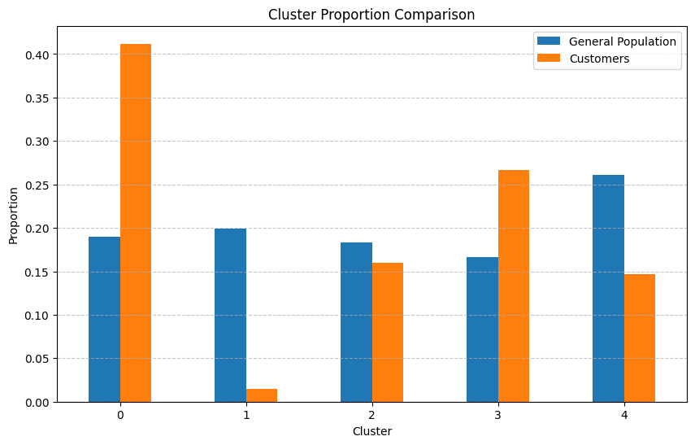

```python
# Compare the proportion of data in each cluster for the customer data to the
# proportion of data in each cluster for the general population.

# Step 1: Count cluster assignments for general population
general_population_cluster_counts = pd.Series(kmeans_final.labels_).value_counts(normalize=True)
general_population_cluster_proportions = general_population_cluster_counts.sort_index()

# Step 2: Count cluster assignments for customers
customer_cluster_counts = cleaned_customers['Cluster'].value_counts(normalize=True)
customer_cluster_proportions = customer_cluster_counts.sort_index()

# Step 3: Combine proportions into a single DataFrame for comparison
comparison_df = pd.DataFrame({
    'General Population': general_population_cluster_proportions,
    'Customers': customer_cluster_proportions
})

# Fill NaN values with 0 (in case any clusters are missing in the customer data)
comparison_df.fillna(0, inplace=True)

print("Cluster Proportion Comparison:")
print(comparison_df)

# Step 4: Plot the comparison
import matplotlib.pyplot as plt

comparison_df.plot(kind='bar', figsize=(10, 6))
plt.title('Cluster Proportion Comparison')
plt.xlabel('Cluster')
plt.ylabel('Proportion')
plt.xticks(rotation=0)
plt.grid(axis='y', linestyle='--', alpha=0.7)
plt.legend(loc='upper right')
plt.show()
```

```python
# What kinds of people are part of a cluster that is overrepresented in the
# customer data compared to the general population?

# Calculate the difference in representation
comparison_df['Difference'] = comparison_df['Customers'] - comparison_df['General Population']

# Identify overrepresented and underrepresented clusters
overrepresented_clusters = comparison_df[comparison_df['Difference'] > 0].index

print("Overrepresented Clusters in Customer Data:", overrepresented_clusters)
```

```
Overrepresented Clusters in Customer Data: Index([0, 3], dtype='int32')
```

```python
# What kinds of people are part of a cluster that is underrepresented in the
# customer data compared to the general population?

underrepresented_clusters = comparison_df[comparison_df['Difference'] < 0].index
print("Underrepresented Clusters in Customer Data:", underrepresented_clusters)
```

```
Underrepresented Clusters in Customer Data: Index([1, 2, 4], dtype='int32')
```

```python
# Get the cluster centroids in PCA-transformed space
cluster_centroids = kmeans_final.cluster_centers_

# Inverse transform the centroids of overrepresented clusters
for cluster in overrepresented_clusters:
    # Centroid in PCA space
    centroid_pca_space = cluster_centroids[cluster]

    # Inverse transform to original feature space
    centroid_original_space = pca.inverse_transform(centroid_pca_space)

    # Create a DataFrame for easier interpretation
    cluster_features = pd.DataFrame({
        'Feature': df_demograph.columns,
        'Value': centroid_original_space
    }).sort_values(by='Value', ascending=False)

    print(f"\nCluster {cluster} - Top Features in Original Space:")
    print(cluster_features.head(10))  # Top 10 prominent features
```

```
Cluster 0 - Top Features in Original Space:
              Feature     Value
3   FINANZ_MINIMALIST  1.184877
18     LP_STATUS_GROB  0.970137
17     LP_STATUS_FEIN  0.941001
1           ANREDE_KZ  0.897730
26         SEMIO_VERT  0.889451
61         MOBI_REGIO  0.772901
51        KBA05_ANTG1  0.747284
55          KBA05_GBZ  0.684013
65         PLZ8_ANTG1  0.632927
5    FINANZ_VORSORGER  0.569457

Cluster 3 - Top Features in Original Space:
                  Feature     Value
35            SEMIO_TRADV  0.996220
20  PRAEGENDE_JUGENDJAHRE  0.976655
34          SEMIO_PFLICHT  0.968117
6          FINANZ_ANLEGER  0.962436
7   FINANZ_UNAUFFAELLIGER  0.958483
4           FINANZ_SPARER  0.931046
24              SEMIO_REL  0.923090
30              SEMIO_RAT  0.886053
25              SEMIO_MAT  0.638781
62      ONLINE_AFFINITAET  0.623743
```

```python
# Map features to descriptions from the data dictionary
data_dictionary = {
    'INCOME_GROUP': 'Income group of individuals',
    'AGE_GROUP': 'Age group of individuals',
}

# Print feature descriptions for prominent features
for cluster in overrepresented_clusters:
    print(f"\nCluster {cluster} - Key Feature Descriptions:")
    for _, row in cluster_features.head(10).iterrows():
        feature = row['Feature']
        value = row['Value']
        description = data_dictionary.get(feature, "Description not available")
        print(f"{feature} ({description}): {value:.4f}")
```

[output not shown]

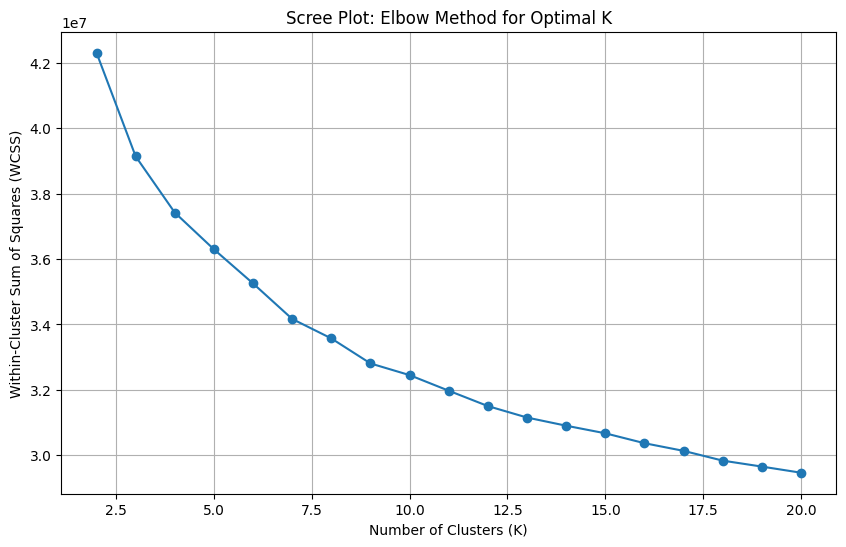

```python
from sklearn.cluster import KMeans

# Range of K values
k_values = range(2, 21)
wcss = []

# Calculate WCSS for each value of K
for k in k_values:
    kmeans = KMeans(n_clusters=k, random_state=42)
    kmeans.fit(df_demograph)  # Replace azdias with your data
    wcss.append(kmeans.inertia_)  # WCSS is stored in inertia_

# Plot the scree plot
plt.figure(figsize=(10, 6))
plt.plot(k_values, wcss, marker='o')
plt.title("Scree Plot: Elbow Method for Optimal K")
plt.xlabel("Number of Clusters (K)")
plt.ylabel("Within-Cluster Sum of Squares (WCSS)")
plt.grid()
plt.show()
```

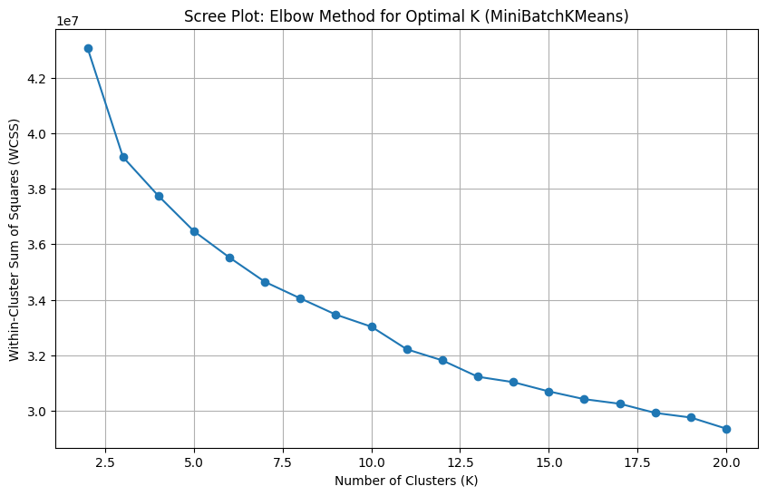

```python
from sklearn.cluster import MiniBatchKMeans

# Calculate WCSS for MiniBatchKMeans
wcss = []
for k in k_values:
    minibatch_kmeans = MiniBatchKMeans(n_clusters=k, random_state=42, batch_size=1024)
    minibatch_kmeans.fit(df_demograph)
    wcss.append(minibatch_kmeans.inertia_)

# Scree plot
plt.figure(figsize=(10, 6))
plt.plot(k_values, wcss, marker='o')
plt.title("Scree Plot: Elbow Method for Optimal K (MiniBatchKMeans)")
plt.xlabel("Number of Clusters (K)")
plt.ylabel("Within-Cluster Sum of Squares (WCSS)")
plt.grid()
plt.show()
```

### Discussion 3.3: Compare Customer Data to Demographics Data

> After segmenting both the general population (azdias or df_demograph) and the customer dataset using the same clustering model, we compared the relative proportions of each cluster across the two datasets. This comparison highlighted which segments are more or less engaged with the mail-order company.

> These segments may find the mail-order business model less appealing due to budget limitations or differing lifestyle preferences.

> Strategic Recommendations:
> - Continue nurturing high-value customer segments through loyalty initiatives and tailored offerings.
> - Explore opportunities to engage younger, underrepresented demographics by:
>   - Offering more affordable or trend-oriented products.
>   - Adopting modern digital marketing strategies and platforms.
>   - Emphasizing flexible shopping or delivery options.

> This analysis provides a foundation for targeted customer engagement and strategic growth, enabling the company to optimize both retention and acquisition efforts.